# Trabajo grupal - Asignatura 3 - Grupo 4

2024-04-19

Integrantes:

- Pablo Clemente Briceño
- Chu Xin Morales Chacón
- John Fredy Cabrera Arciniegas
- Juan Moscardó

# Reto

- 1. Realizar un análisis exploratorio del conjunto de datos, investigando las variables que se crea que son más relevantes, justificando el procesado y las transformaciones que sean necesarias para llevarlo a cabo (20%)
- 2. Obtener dos modelos predictivos de clasificación binaria (30%). Evaluar los modelos y analizar las métricas pertinentes:
  - 2.1. Un modelo que detecte en base a los datos si un usuario es fumador o no.
  - 2.2. Un modelo que detecte en base a los datos si un usuario controla o no lascalorías ingeridas.
- 3. Obtener un modelo predictivo de clasificación multiclase que en base a los datos obtenga el grado de obesidad de una persona (30%). Evaluar el modelo y analizar las métricas pertinentes.
- 4. Aplicar técnicas de clustering para segmentar a la población del dataset (20%).Evaluarlos modelos y analizar las métricas pertinentes

# Datos

La siguiente tabla de estudio contiene datos sobre la estimación de los niveles de personas obesas en México, Peru y Colombia, para ello se ha usado un grupo de personas de entre 14 a 61 años, todos ellos con diferentes hábitos alimenticios y condición física. El estudio se ha llevado a cabo recolectando una serie de datos en una plataforma de encuesta, en donde dicho grupo ha tenido que contestar de manera anónima una serie de preguntas con una serie de respuestas, dando como resultado 17 variables. Los valores que se han usado son características/atributos relacionados con los hábitos alimenticios, y la condición física del grupo estudiado.

## Preguntas del cuestionario.

Encuesta para la recopilación inicial de información. Preguntas y posibles respuestas:

- Sexo: Femenino - Masculino
- Edad: Valor numérico
- Estatura: Valor numérico en metros
- Peso: Valor numérico en kilogramos
- ¿Algún familiar ha sufrido o sufre de sobrepeso?: Sí - No
- ¿Consume alimentos con alto contenido calórico frecuentemente?: Sí - No
- ¿Suele comer verduras en sus comidas?: Nunca - Algunas veces - Siempre
- ¿Cuántas comidas principales tiene al día?: Entre 1 y 2 - Tres - Más de tres
- ¿Come algo entre comidas?: No - Algunas veces - Frecuentemente - Siempre
- ¿Fuma?: Sí - No
- ¿Cuánta agua bebe diariamente?: Menos de un litro - Entre 1 y 2 litros - Más de 2 litros
- ¿Controla las calorías que consume diariamente?: Sí - No
- ¿Con qué frecuencia realiza actividad física?: No realizo - 1 o 2 días - 2 o 4 días - 4 o 5 días
- ¿Cuánto tiempo utiliza dispositivos tecnológicos como celular, videojuegos, televisión, computadora y otros?: 0 a 2 horas - 3 a 5 horas - Más de 5 horas
- ¿Con qué frecuencia consume alcohol?: No bebo - Algunas veces - Frecuentemente - Siempre
- ¿Qué medio de transporte utiliza habitualmente?: Automóvil - Motocicleta - Bicicleta - Transporte público - Caminando

| Variables | Descripción |
| --- | --- |
| FAVC | Frecuencia de consumición de alimentos altos en calorías |
| FCVC | Frecuencia en consumición de vegetales |
| NCP | Número de comidas al día |
| CAEC | Consumición de picoteo entre comidas |
| CH20 | Consumición de agua diaria |
| CALC | Consumición de bebidas alcohólicas |
| SMOKE | Fumador |
| SCC | Monitoreo de las calorías consumidas |
| FAF | Frecuencia de realización de actividad física |
| TUE | Tiempo dedicado a usar los dispositivos digitales |
| MTRANS | Tipo de uso de transporte |
| Género | Datos generales |
| Edad | Datos generales |
| Años | Datos generales |
| Estatura | Datos generales |
| Peso | Datos generales |
| Historia familiar con obesidad registrada | Datos generales |

Finalmente, los resultados se han categorizados, en nuevas variables dependiendo del tipo de peso;

- Insuficiente peso
- Peso normal
- Sobrepeso nivel 1
- Sobrepeso nivel 2
- Obesidad tipo 1
- Obesidad tipo 2
- Obesidad tipo 3

# 1. Análisis

De las diecisiete variables que tenemos nueve han tenido que ser transformadas para poder ser estudiadas en nuestro data set.

```r
library(corrplot)
library(car)
library(caret)
library(cluster)
library(DiagrammeR)
library(dplyr)
library(e1071)
library(factoextra)
library(ggplot2)
library(GGally)
library(mltools)
library(rpart)
library(rpart.plot)
library(randomForest)
library(scales)
library(stats)
library(tidyverse)
library(visreg)
```

Solucion al reto propuesto en foro de la Asignatura 3 para el Master en BigData y BI

A continuacion se detallan los pasos de nuestra solucion al reto

## Carga de datos

```r
obesity = read.csv("ObesityDataSet_raw_and_data_sinthetic.csv",header=TRUE, sep = ",")
dim(obesity)
```

```
## [1] 2111   17
```

```r
head(obesity)
```

```
##   Gender Age Height Weight family_history_with_overweight FAVC FCVC NCP
## 1 Female  21   1.62   64.0                            yes   no    2   3
## 2 Female  21   1.52   56.0                            yes   no    3   3
## 3   Male  23   1.80   77.0                            yes   no    2   3
## 4   Male  27   1.80   87.0                             no   no    3   3
## 5   Male  22   1.78   89.8                             no   no    2   1
## 6   Male  29   1.62   53.0                             no  yes    2   3
##        CAEC SMOKE CH2O SCC FAF TUE       CALC                MTRANS
## 1 Sometimes    no    2  no   0   1         no Public_Transportation
## 2 Sometimes   yes    3 yes   3   0  Sometimes Public_Transportation
## 3 Sometimes    no    2  no   2   1 Frequently Public_Transportation
## 4 Sometimes    no    2  no   2   0 Frequently               Walking
## 5 Sometimes    no    2  no   0   0  Sometimes Public_Transportation
## 6 Sometimes    no    2  no   0   0  Sometimes            Automobile
##            NObeyesdad
## 1       Normal_Weight
## 2       Normal_Weight
## 3       Normal_Weight
## 4  Overweight_Level_I
## 5 Overweight_Level_II
## 6       Normal_Weight
```

## Exploracion de datos

```r
str(obesity)
```

```
## 'data.frame':    2111 obs. of  17 variables:
##  $ Gender                        : chr  "Female" "Female" "Male" "Male" ...
##  $ Age                           : num  21 21 23 27 22 29 23 22 24 22 ...
##  $ Height                        : num  1.62 1.52 1.8 1.8 1.78 1.62 1.5 1.64 1.78 1.72 ...
##  $ Weight                        : num  64 56 77 87 89.8 53 55 53 64 68 ...
##  $ family_history_with_overweight: chr  "yes" "yes" "yes" "no" ...
##  $ FAVC                          : chr  "no" "no" "no" "no" ...
##  $ FCVC                          : num  2 3 2 3 2 2 3 2 3 2 ...
##  $ NCP                           : num  3 3 3 3 1 3 3 3 3 3 ...
##  $ CAEC                          : chr  "Sometimes" "Sometimes" "Sometimes" "Sometimes" ...
##  $ SMOKE                         : chr  "no" "yes" "no" "no" ...
##  $ CH2O                          : num  2 3 2 2 2 2 2 2 2 2 ...
##  $ SCC                           : chr  "no" "yes" "no" "no" ...
##  $ FAF                           : num  0 3 2 2 0 0 1 3 1 1 ...
##  $ TUE                           : num  1 0 1 0 0 0 0 0 1 1 ...
##  $ CALC                          : chr  "no" "Sometimes" "Frequently" "Frequently" ...
##  $ MTRANS                        : chr  "Public_Transportation" "Public_Transportation" "Public_Transportation" "Walking" ...
##  $ NObeyesdad                    : chr  "Normal_Weight" "Normal_Weight" "Normal_Weight" "Overweight_Level_I" ...
```

Verificar falta de datos para cada variable

```r
colSums(is.na(obesity))
```

```
##                         Gender                            Age
##                              0                              0
##                         Height                         Weight
##                              0                              0
## family_history_with_overweight                           FAVC
##                              0                              0
##                           FCVC                            NCP
##                              0                              0
##                           CAEC                          SMOKE
##                              0                              0
##                           CH2O                            SCC
##                              0                              0
##                            FAF                            TUE
##                              0                              0
##                           CALC                         MTRANS
##                              0                              0
##                     NObeyesdad
##                              0
```

```r
colSums(obesity=="")
```

```
##                         Gender                            Age
##                              0                              0
##                         Height                         Weight
##                              0                              0
## family_history_with_overweight                           FAVC
##                              0                              0
##                           FCVC                            NCP
##                              0                              0
##                           CAEC                          SMOKE
##                              0                              0
##                           CH2O                            SCC
##                              0                              0
##                            FAF                            TUE
##                              0                              0
##                           CALC                         MTRANS
##                              0                              0
##                     NObeyesdad
##                              0
```

Parece que el dataset no tiene datos faltantes.

Verificar los valores de las edades con una tabla de frecuencias

```r
head(table(obesity$Age),50)
```

```
##
##        14        15        16 16.093234 16.129279 16.172992 16.198153 16.240576
##         1         1         9         1         1         1         1         1
## 16.270434  16.30687 16.370009  16.38009 16.496978 16.611837 16.613108 16.834813
##         1         2         1         1         1         1         1         1
## 16.865984 16.910997 16.913841 16.928791 16.941489 16.950499        17 17.000433
##         1         1         1         1         1         1        30         1
## 17.000752 17.038222 17.039058 17.052914 17.065445  17.06713 17.073648 17.080493
##         1         1         1         1         1         1         1         1
## 17.082867  17.08525 17.099015 17.120699 17.178483 17.188754 17.203917 17.210933
##         1         1         1         1         1         1         1         1
##  17.25813 17.282945 17.362129 17.377131 17.402028 17.405104 17.412629 17.420269
##         1         1         1         1         1         1         1         1
## 17.441593 17.451085
##         1         1
```

la edad tiene valores decimales, la transformaremos a enteros para que la data sea consecuente con lo que debe representar

```r
obesity$Age = round(obesity$Age,)
```

inicialmente parece que las variables FCVC, NCP, CH2O, FAF y TUE ya tienen un valor numerico o ya han sido transformadas o manipuladas.

```r
print("FCVC")
```

```
## [1] "FCVC"
```

```r
summary(obesity$FCVC)
```

```
##    Min. 1st Qu.  Median    Mean 3rd Qu.    Max.
##   1.000   2.000   2.386   2.419   3.000   3.000
```

```r
print("NCP")
```

```
## [1] "NCP"
```

```r
summary(obesity$NCP)
```

```
##    Min. 1st Qu.  Median    Mean 3rd Qu.    Max.
##   1.000   2.659   3.000   2.686   3.000   4.000
```

```r
print("CH2O")
```

```
## [1] "CH2O"
```

```r
summary(obesity$CH2O)
```

```
##    Min. 1st Qu.  Median    Mean 3rd Qu.    Max.
##   1.000   1.585   2.000   2.008   2.477   3.000
```

```r
print("FAF")
```

```
## [1] "FAF"
```

```r
summary(obesity$FAF)
```

```
##    Min. 1st Qu.  Median    Mean 3rd Qu.    Max.
##  0.0000  0.1245  1.0000  1.0103  1.6667  3.0000
```

```r
print("TUE")
```

```
## [1] "TUE"
```

```r
summary(obesity$TUE)
```

```
##    Min. 1st Qu.  Median    Mean 3rd Qu.    Max.
##  0.0000  0.0000  0.6253  0.6579  1.0000  2.0000
```

verificar los valores maximos

```r
print("FCVC")
```

```
## [1] "FCVC"
```

```r
dim(obesity[obesity$FCVC > 2.9,])
```

```
## [1] 751  17
```

```r
print("NCP")
```

```
## [1] "NCP"
```

```r
dim(obesity[obesity$NCP > 3.9,])
```

```
## [1] 90 17
```

```r
print("CH2O")
```

```
## [1] "CH2O"
```

```r
dim(obesity[obesity$CH2O > 2.9,])
```

```
## [1] 213  17
```

```r
print("FAF")
```

```
## [1] "FAF"
```

```r
dim(obesity[obesity$FAF > 2.9,])
```

```
## [1] 81 17
```

```r
print("TUE")
```

```
## [1] "TUE"
```

```r
dim(obesity[obesity$TUE > 1.9,])
```

```
## [1] 131  17
```

## Primeras transformaciones

Los valores posibles de la variable FCVC segun la encuesta son (Nunca - Algunas veces - Siempre) y teniendo en cuenta que los valores minimos en esta variable son 1 y los maximos son 3 podriamos transformar la variable para que solo tenga en cuenta el valor entero y este corresponda a la codificacion de las posibles respuestas.

```r
obesity$FCVC = round(obesity$FCVC,)
```

Los valores posibles de la variable CH2O segun la encuesta son (Menos de un litro - Entre 1 y 2 litros - Más de 2 litros) y teniendo en cuenta que los valores minimos en esta variable son 1 y los maximos son 3 podriamos transformar la variable para que solo tenga en cuenta el valor entero y este corresponda a la codificacion de las posibles respuestas.

```r
obesity$CH2O = round(obesity$CH2O,)
```

Los valores posibles de la variable NCP segun la encuesta son (Entre 1 y 2 - Tres - Más de tres) sin embargo los datos tienen una distribucion que no parece codificar estas opciones. Para este caso, se redondearan los datos para dejar esta variable como discreta representando el numero de comidas al día.

```r
obesity$NCP = round(obesity$NCP,)
```

Los valores posibles de la variable FAF segun la encuesta son (No realizo - 1 o 2 días - 2 o 4 días - 4 o 5 días) sin embargo los datos tienen una distribucion que no parece codificar estas opciones. Para este caso, se redondearan los datos para dejar esta variable como discreta reperesentando el numero de dias que realiza actividad física en la semana.

```r
obesity$FAF = round(obesity$FAF,)
```

Los valores posibles de la variable TUE segun la encuesta son (0 a 2 horas - 3 a 5 horas - Más de 5 horas) sin embargo los datos tienen una distribucion que no parece codificar estas opciones. Para este caso, se redondearan los datos para dejar esta variable como discreta reperesentando el numero de horas que utiliza dispositivos tecnológicos.

```r
obesity$TUE = round(obesity$TUE,)
```

Una vez redondeados, pasamos las variables a factor.

```r
print("FCVC")
```

```
## [1] "FCVC"
```

```r
obesity$FCVC <- as.factor(obesity$FCVC)
print("NCP")
```

```
## [1] "NCP"
```

```r
obesity$NCP <- as.factor(obesity$NCP)
print("CH2O")
```

```
## [1] "CH2O"
```

```r
obesity$CH2O <- as.factor(obesity$CH2O)
print("FAF")
```

```
## [1] "FAF"
```

```r
obesity$FAF <- as.factor(obesity$FAF)
print("TUE")
```

```
## [1] "TUE"
```

```r
obesity$TUE <- as.factor(obesity$TUE)
```

Verificamos los datos de las variables categoricas

```r
unique(obesity$Gender)
```

```
## [1] "Female" "Male"
```

```r
unique(obesity$family_history_with_overweight)
```

```
## [1] "yes" "no"
```

```r
unique(obesity$FAVC)
```

```
## [1] "no"  "yes"
```

```r
unique(obesity$CAEC)
```

```
## [1] "Sometimes"  "Frequently" "Always"     "no"
```

```r
unique(obesity$SMOKE)
```

```
## [1] "no"  "yes"
```

```r
unique(obesity$SCC)
```

```
## [1] "no"  "yes"
```

```r
unique(obesity$CALC)
```

```
## [1] "no"         "Sometimes"  "Frequently" "Always"
```

```r
unique(obesity$MTRANS)
```

```
## [1] "Public_Transportation" "Walking"               "Automobile"
## [4] "Motorbike"             "Bike"
```

```r
unique(obesity$NObeyesdad)
```

```
## [1] "Normal_Weight"       "Overweight_Level_I"  "Overweight_Level_II"
## [4] "Obesity_Type_I"      "Insufficient_Weight" "Obesity_Type_II"
## [7] "Obesity_Type_III"
```

transformar variables de categoricas a factor

```r
obesity$Gender <- as.factor(obesity$Gender)
obesity$family_history_with_overweight <- as.factor(obesity$family_history_with_overweight)
obesity$FAVC <- as.factor(obesity$FAVC)
obesity$CAEC <- as.factor(obesity$CAEC)
obesity$SMOKE <- as.factor(obesity$SMOKE)
obesity$SCC <- as.factor(obesity$SCC)
obesity$CALC <- as.factor(obesity$CALC)
obesity$MTRANS <- as.factor(obesity$MTRANS)
obesity$NObeyesdad <- as.factor(obesity$NObeyesdad)
str(obesity)
```

```
## 'data.frame':    2111 obs. of  17 variables:
##  $ Gender                        : Factor w/ 2 levels "Female","Male": 1 1 2 2 2 2 1 2 2 2 ...
##  $ Age                           : num  21 21 23 27 22 29 23 22 24 22 ...
##  $ Height                        : num  1.62 1.52 1.8 1.8 1.78 1.62 1.5 1.64 1.78 1.72 ...
##  $ Weight                        : num  64 56 77 87 89.8 53 55 53 64 68 ...
##  $ family_history_with_overweight: Factor w/ 2 levels "no","yes": 2 2 2 1 1 1 2 1 2 2 ...
##  $ FAVC                          : Factor w/ 2 levels "no","yes": 1 1 1 1 1 2 2 1 2 2 ...
##  $ FCVC                          : Factor w/ 3 levels "1","2","3": 2 3 2 3 2 2 3 2 3 2 ...
##  $ NCP                           : Factor w/ 4 levels "1","2","3","4": 3 3 3 3 1 3 3 3 3 3 ...
##  $ CAEC                          : Factor w/ 4 levels "Always","Frequently",..: 4 4 4 4 4 4 4 4 4 4 ...
##  $ SMOKE                         : Factor w/ 2 levels "no","yes": 1 2 1 1 1 1 1 1 1 1 ...
##  $ CH2O                          : Factor w/ 3 levels "1","2","3": 2 3 2 2 2 2 2 2 2 2 ...
##  $ SCC                           : Factor w/ 2 levels "no","yes": 1 2 1 1 1 1 1 1 1 1 ...
##  $ FAF                           : Factor w/ 4 levels "0","1","2","3": 1 4 3 3 1 1 2 4 2 2 ...
##  $ TUE                           : Factor w/ 3 levels "0","1","2": 2 1 2 1 1 1 1 1 2 2 ...
##  $ CALC                          : Factor w/ 4 levels "Always","Frequently",..: 3 4 2 2 4 4 4 4 2 3 ...
##  $ MTRANS                        : Factor w/ 5 levels "Automobile","Bike",..: 4 4 4 5 4 1 3 4 4 4 ...
##  $ NObeyesdad                    : Factor w/ 7 levels "Insufficient_Weight",..: 2 2 2 6 7 2 2 2 2 2 ...
```

```r
summary(obesity)
```

```
##     Gender          Age            Height          Weight
##  Female:1043   Min.   :14.00   Min.   :1.450   Min.   : 39.00
##  Male  :1068   1st Qu.:20.00   1st Qu.:1.630   1st Qu.: 65.47
##                Median :23.00   Median :1.700   Median : 83.00
##                Mean   :24.32   Mean   :1.702   Mean   : 86.59
##                3rd Qu.:26.00   3rd Qu.:1.768   3rd Qu.:107.43
##                Max.   :61.00   Max.   :1.980   Max.   :173.00
##
##  family_history_with_overweight  FAVC      FCVC     NCP              CAEC
##  no : 385                       no : 245   1: 102   1: 316   Always    :  53
##  yes:1726                       yes:1866   2:1013   2: 176   Frequently: 242
##                                            3: 996   3:1470   no        :  51
##                                                     4: 149   Sometimes :1765
##
##
##
##  SMOKE      CH2O      SCC       FAF     TUE             CALC
##  no :2067   1: 485   no :2015   0:720   0:952   Always    :   1
##  yes:  44   2:1110   yes:  96   1:776   1:915   Frequently:  70
##             3: 516              2:496   2:244   no        : 639
##                                 3:119           Sometimes :1401
##
##
##
##                    MTRANS                   NObeyesdad
##  Automobile           : 457   Insufficient_Weight:272
##  Bike                 :   7   Normal_Weight      :287
##  Motorbike            :  11   Obesity_Type_I     :351
##  Public_Transportation:1580   Obesity_Type_II    :297
##  Walking              :  56   Obesity_Type_III   :324
##                               Overweight_Level_I :290
##                               Overweight_Level_II:290
```

## Tipos de variables

Luego de un primer Vistazo al dataset podemos definir los tipos de variables

```r
DiagrammeR("
graph LR;
  B[Cualitativas] -->|tipo| D[Nominales];
  B -->|tipo| E[Ordinales];
  D --> H[FAVC];
  D --> I[SMOKE];
  D --> J[Gender];
  D --> K[SCC];
  D --> L[family_history_with_overweight];
  E --> M[NCP];
  E --> O[FCVC];
  E --> P[CH20];
  E --> Q[FAF];
  E --> R[TUE];
  E --> S[CAEC];
  E --> T[CALC];
  E --> U[MTRANS];
  E --> V[NObeyesdad];
")
```

[interactive chart not shown]

```r
DiagrammeR("
graph LR;
  C[Cuantitativas] -->|tipo| F[Discretas];
  C -->|tipo| G[Continuas];
  F --> P[Age];
  G --> W[Height];
  G --> X[Weight];
")
```

[interactive chart not shown]

## Grafico de distribuciones de las variables

### Graficamos algunas de las variables para ver si guardan relación con la etiqueta de clase a simple vista.

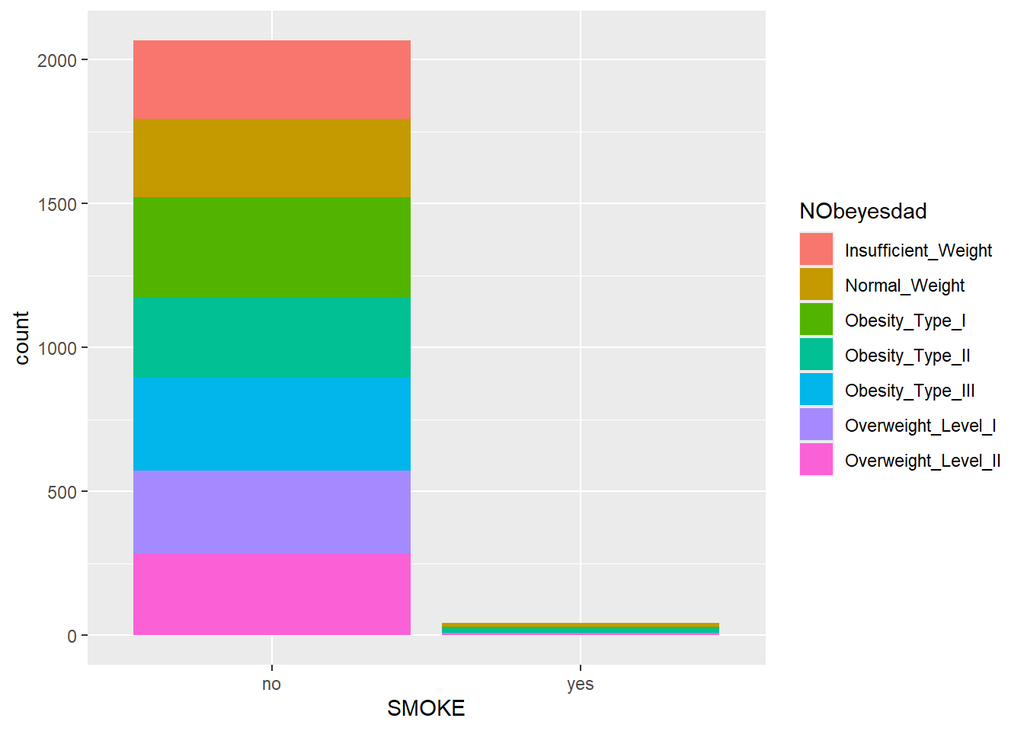

```r
ggplot(data=obesity,aes(x=SMOKE,fill=NObeyesdad))+geom_bar()
```

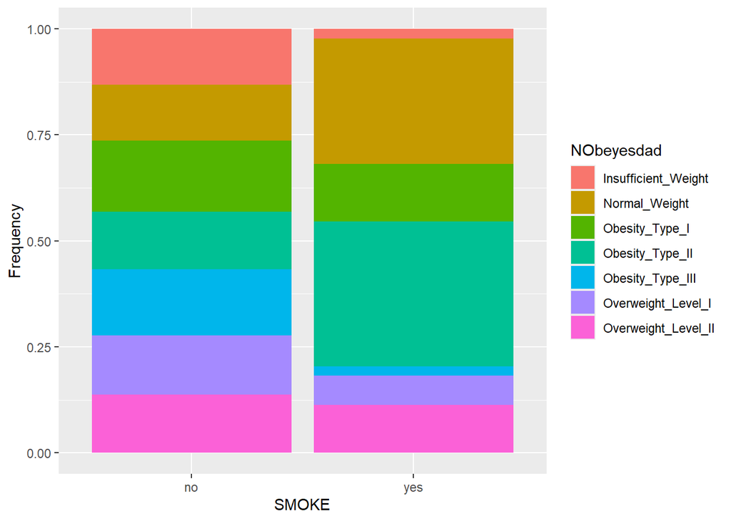

```r
ggplot(data=obesity,aes(x=SMOKE,fill=NObeyesdad))+geom_bar(position="fill")+ylab("Frequency")
```

En términos absolutos vemos que hay muy pocos individuos fumadores en nuestro dataset, en términos relativos vemos que el porcentaje de cada etiqueta está muy repartido en la categoría de no fumadores, mientras que en los si fumadores hay un predominio de las categorías “Normal Weight” y “Obesity Type II”.

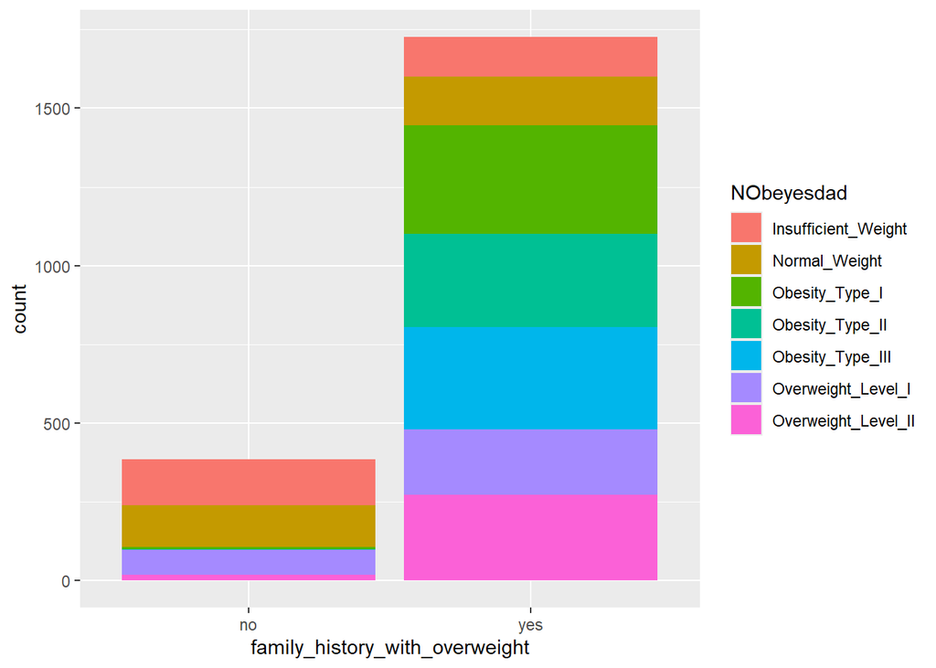

```r
ggplot(data=obesity,aes(x=family_history_with_overweight,fill=NObeyesdad))+geom_bar()
```

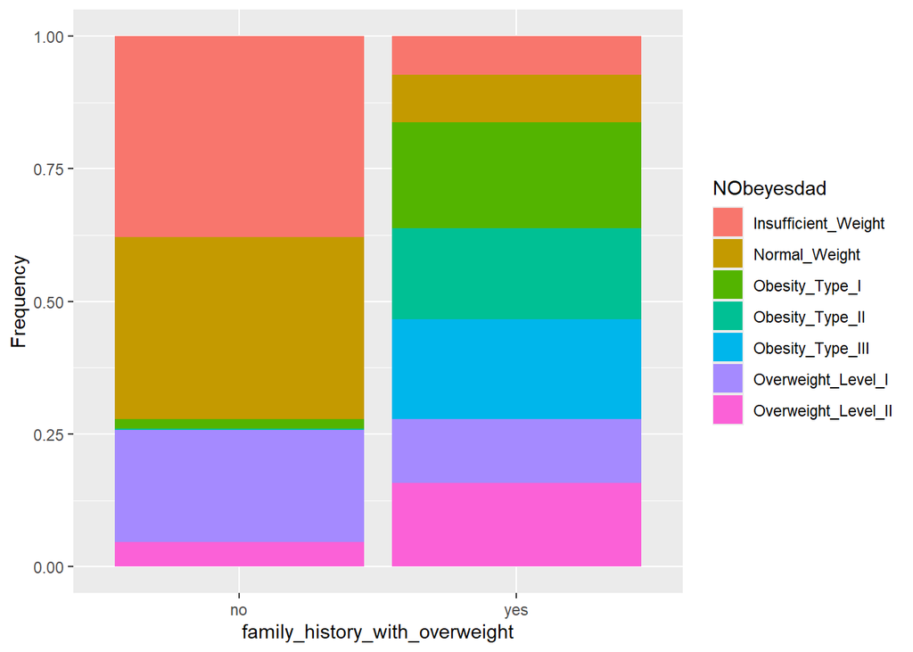

```r
ggplot(data=obesity,aes(x=family_history_with_overweight,fill=NObeyesdad))+geom_bar(position="fill")+ylab("Frequency")
```

Si comparamos si hay antecedentes en la familia de sobrepeso, si que vemos una clara influencia en los individuos donde hay antecedentes, tanto en términos absolutos como relativos. Más del 60% de los sujetos que no tienen antecedentes en la familia se sitúan en las categorías “Insufficient Weight” y “Normal Weight”

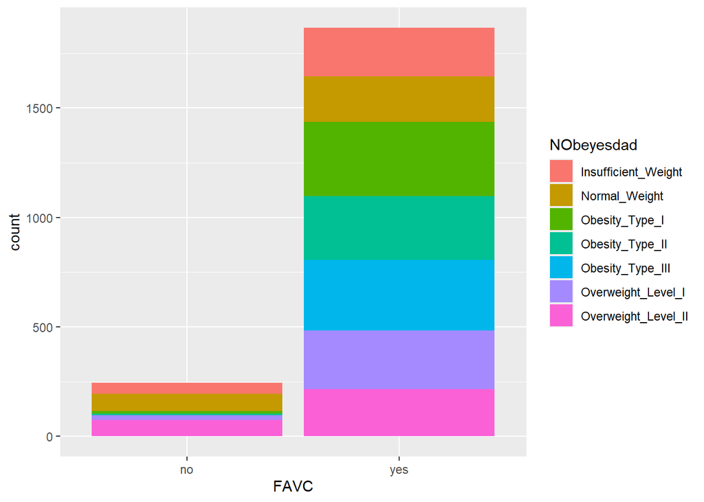

```r
ggplot(data=obesity,aes(x=FAVC,fill=NObeyesdad))+geom_bar()
```

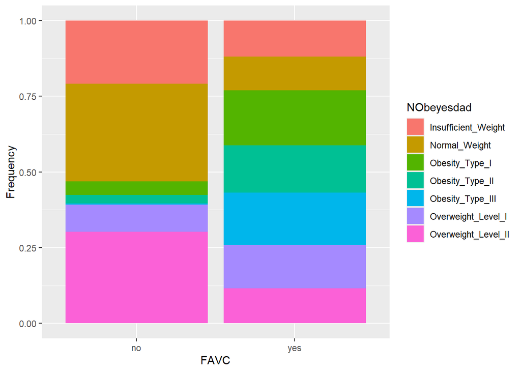

```r
ggplot(data=obesity,aes(x=FAVC,fill=NObeyesdad))+geom_bar(position="fill")+ylab("Frequency")
```

Otra variable interesante para relacionar el sobrepeso con los hábitos alimenticios es FACV (Consumo frecuente de comida hipercalórica), ya que tiene lógica que si se consume de manera habitual la persona tienda mas a un IMC más alto. Los gráficos parece que corroboran esta afirmación, aunque la muestra de las personas que no consumen habitualmente es bastante menor a los que sí.

Para seguir chequeando los hábitos alimentarios de los individuos de la muestra graficaremos también la variable FCVC (Frecuencia con la que se consumen verduras).

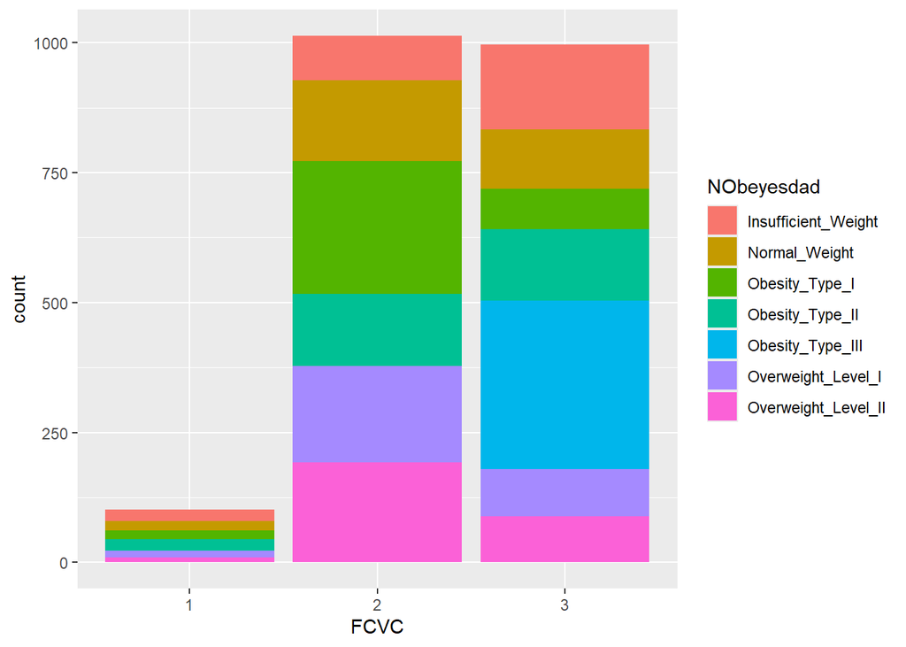

```r
ggplot(data=obesity,aes(x=FCVC ,fill=NObeyesdad))+geom_bar()
```

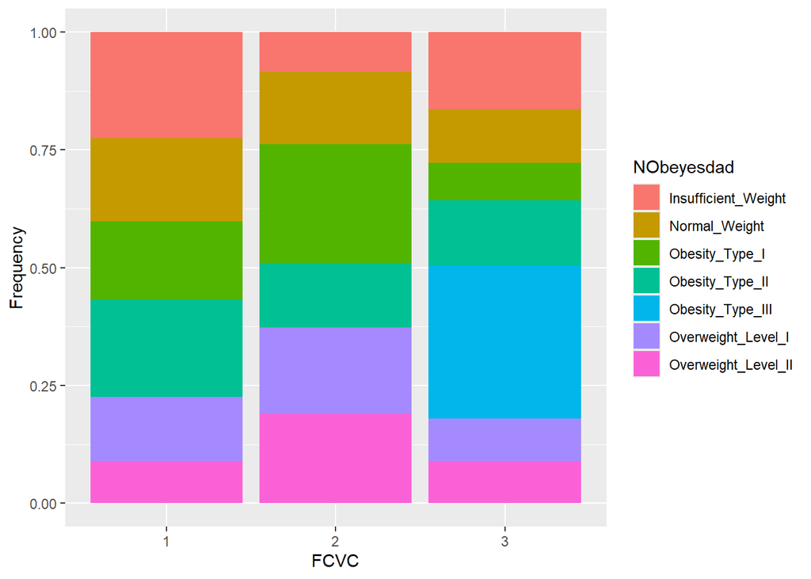

```r
ggplot(data=obesity,aes(x=FCVC ,fill=NObeyesdad))+geom_bar(position="fill")+ylab("Frequency")
```

En términos absolutos vemos que la mayor parte de la muestra consume entre a veces “2” y siempre “3” verduras en las comidas, se observa una tendecia donde los individuos con sobrepeso u obesidad, especialmente los que padecen OBesidad de tipo III, consumen más verduras que las personas con menor IMC, esto puede deberse a que estén siguiendo una dieta para bajar de peso.

Siguiendo con los hábitos alimentarios, vamos a ver como se distribuye la variable clase respecto al número de comidas principales (NCP).

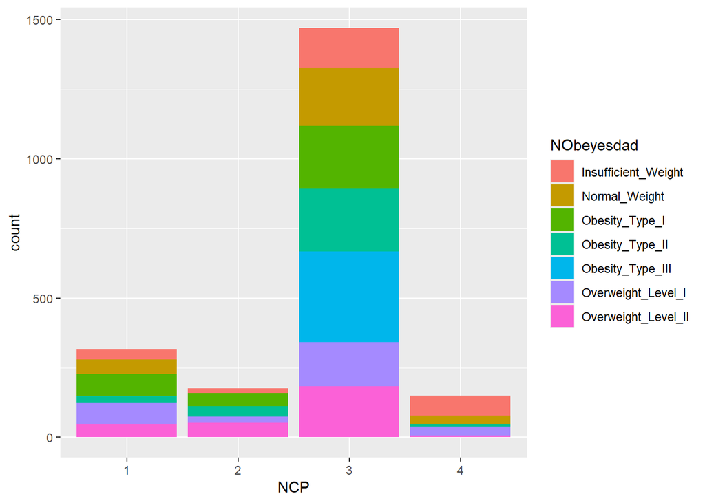

```r
ggplot(data=obesity,aes(x=NCP ,fill=NObeyesdad))+geom_bar()
```

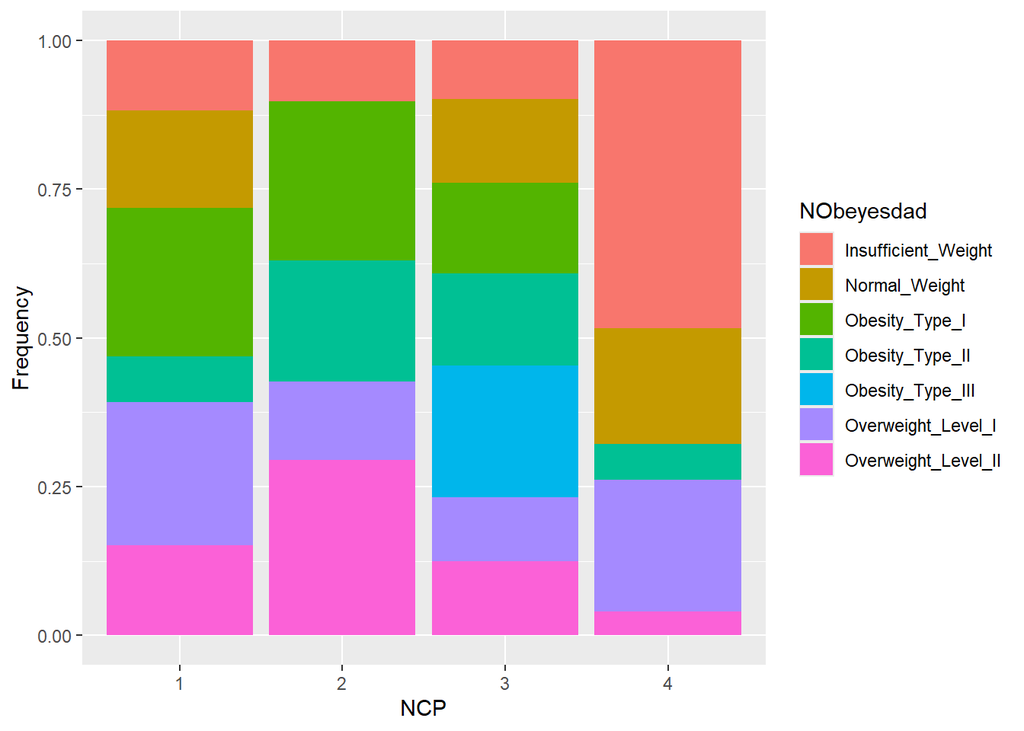

```r
ggplot(data=obesity,aes(x=NCP ,fill=NObeyesdad))+geom_bar(position="fill")+ylab("Frequency")
```

Se ve que la mayoría de la muestra realiza tres comidas principales y que el mayor porcentaje de personas que padecen obesidad o sobrepeso se reparten entre 1, 2 y 3 comidas.

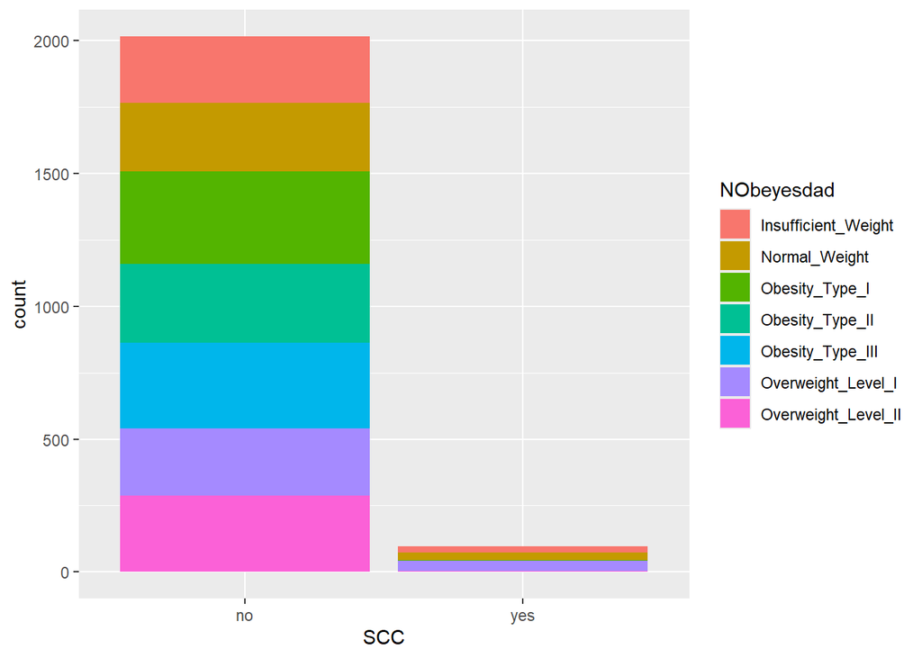

```r
ggplot(data=obesity,aes(x=SCC ,fill=NObeyesdad))+geom_bar()
```

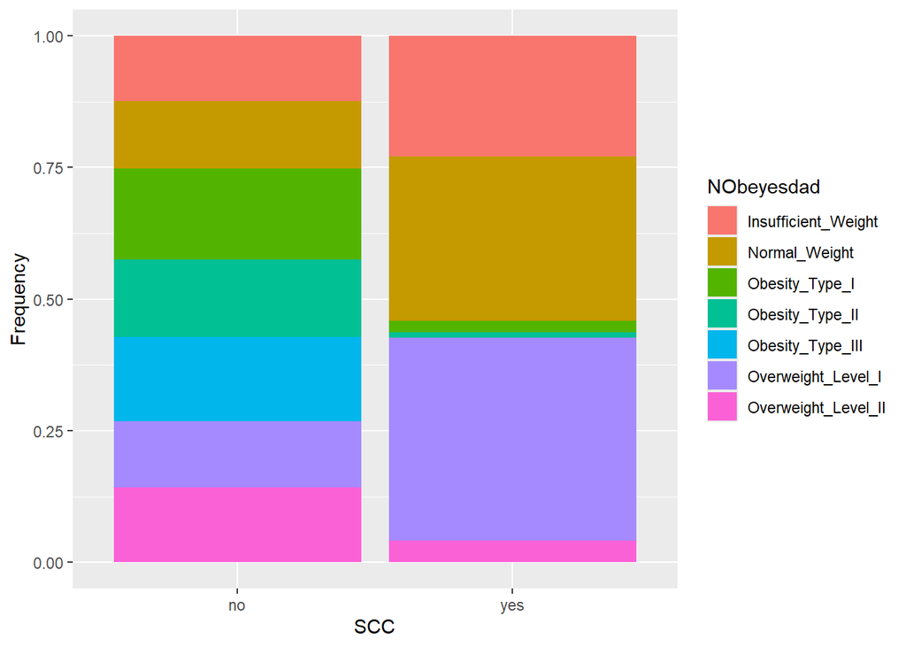

```r
ggplot(data=obesity,aes(x=SCC ,fill=NObeyesdad))+geom_bar(position="fill")+ylab("Frequency")
```

Analizando la variable SCC (Control de calorías ingeridas), se observa que la mayoría de la muestra no las cuenta pero de los que si lo hacen hay un porcentaje muy bajo que padezca obesidad.

Otras variables que pueden ser muiy interesantes para el estudio son las relacionadas con la actividad física, tanto la actividad física del individuo como el medio de transporte que utilizan para desplazarse.

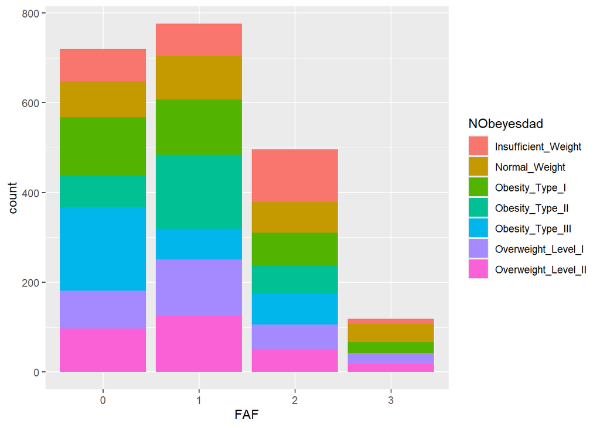

```r
ggplot(data=obesity,aes(x=FAF ,fill=NObeyesdad))+geom_bar()
```

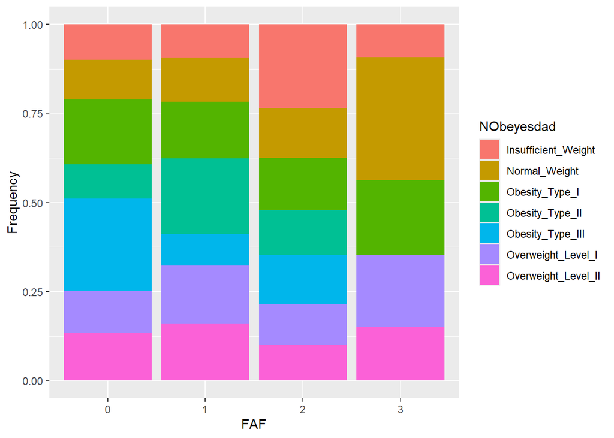

```r
ggplot(data=obesity,aes(x=FAF ,fill=NObeyesdad))+geom_bar(position="fill")+ylab("Frequency")
```

Como es lógico pensar, las persona que realizan atividad física frecuentemente tienen un IMC mas bajo.

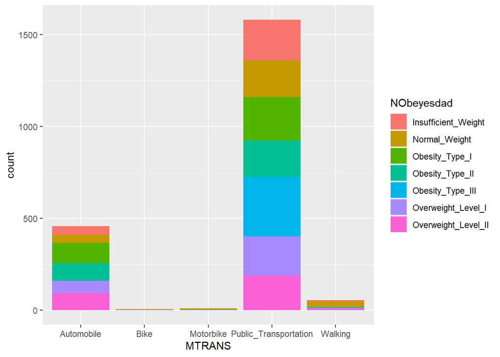

```r
ggplot(data=obesity,aes(x=MTRANS ,fill=NObeyesdad))+geom_bar()
```

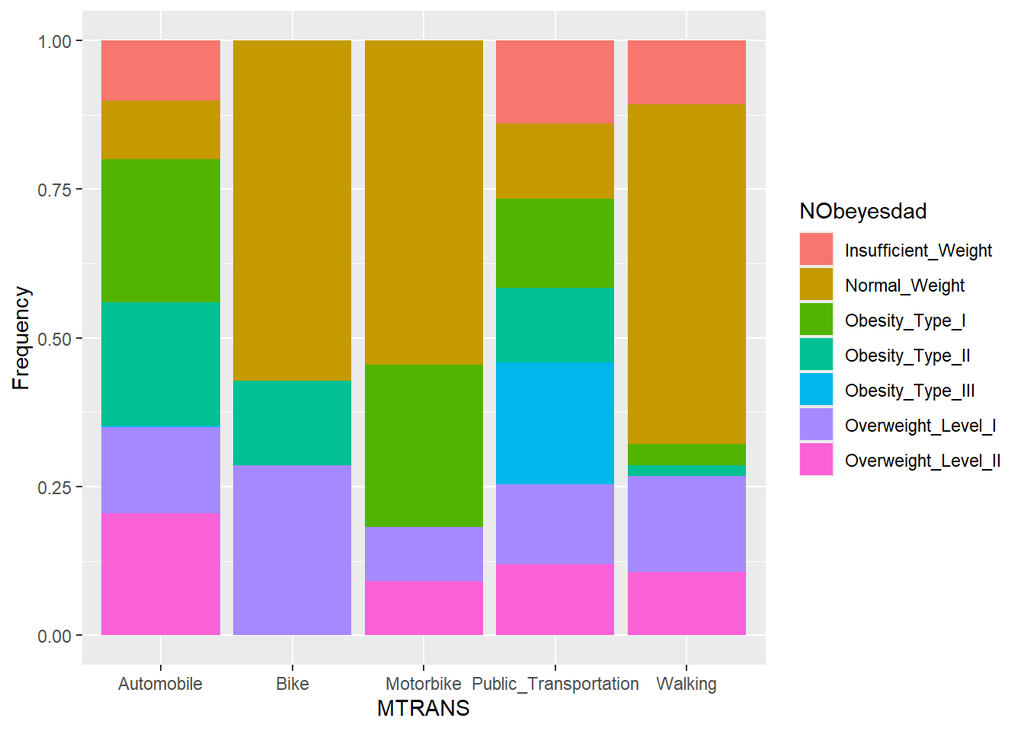

```r
ggplot(data=obesity,aes(x=MTRANS ,fill=NObeyesdad))+geom_bar(position="fill")+ylab("Frequency")
```

Respecto a los medios de transporte, la gran mayoría se desplaza en coche o transporte público,pero en terminos relativos vemos que los medios de transporte que implican actividad física “Walking” y “Bike” tienen un alto porcentaje de personas con “Normal Weight”.

Por último, revisaremos la variable género.

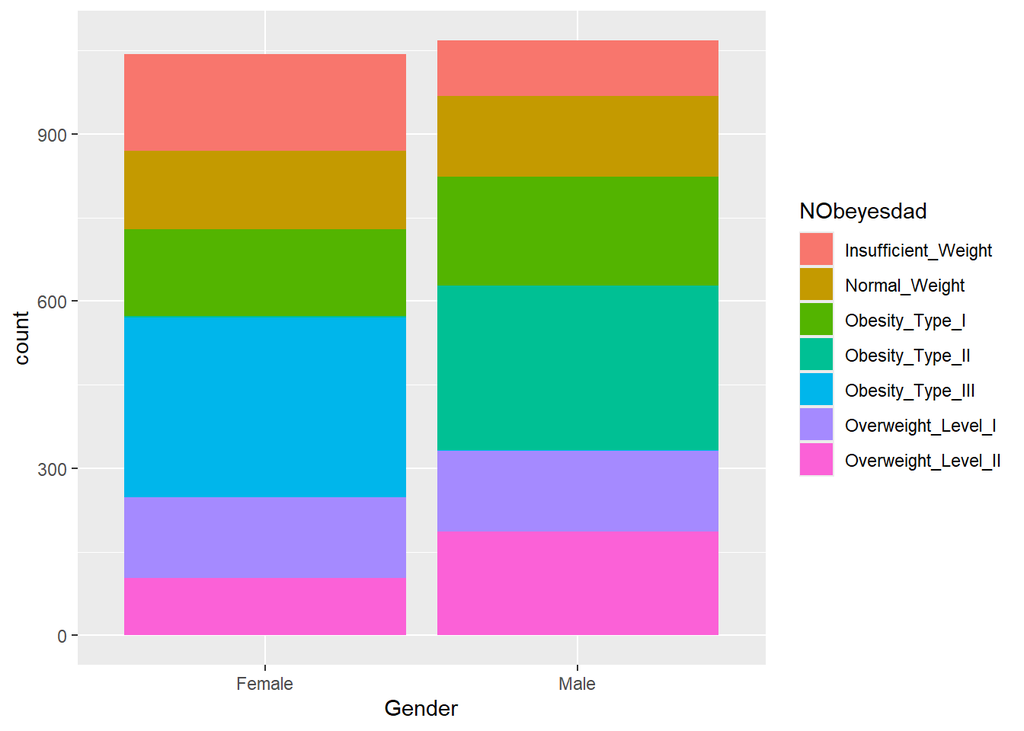

```r
ggplot(data=obesity,aes(x=Gender ,fill=NObeyesdad))+geom_bar()
```

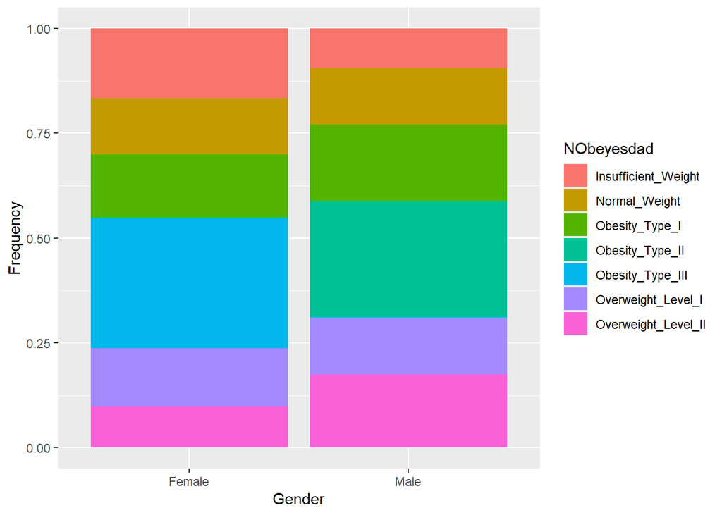

```r
ggplot(data=obesity,aes(x=Gender ,fill=NObeyesdad))+geom_bar(position="fill")+ylab("Frequency")
```

La muestra es bastante pareja en cuanto a número de observaciones, el porcentaje de personas con IMC normal o bajo es ligeramente mayor en las mujeres, sin embargo hay un porcentaje muy grande de la clase “Obesity Type III” mientras que en el género masculino predomina la clase “Obesity Type II”.

verificar correlaciones de variables numericas

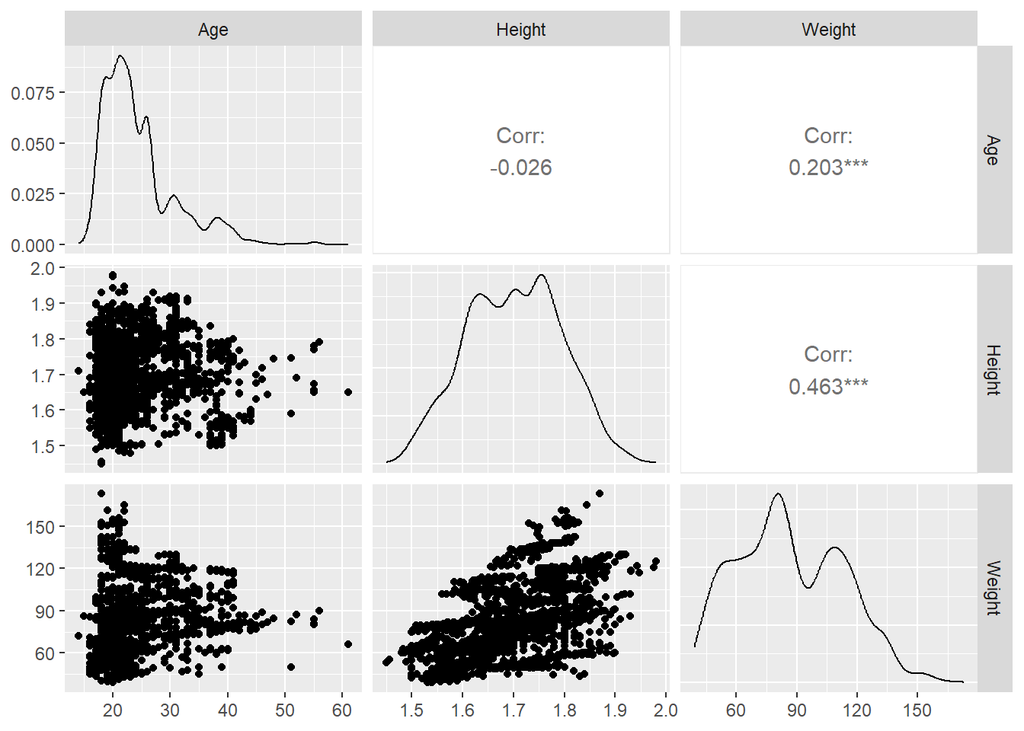

## Transformaciones Siguiendo con las transformaciones, podemos reducir la dimensionalidad del dataset si aplicamos la función del IMC (Índice de masa corporal) que combina el peso entre el cuadrado de la altura y es lo que determina a que clase pertenece cada individuo.

```r
obesity.model= obesity %>%
  mutate(IMC = Weight/(Height^2))
obesity.model= obesity.model %>%
  select(-c(Height,Weight))
head(obesity.model)
```

```
##   Gender Age family_history_with_overweight FAVC FCVC NCP      CAEC SMOKE CH2O
## 1 Female  21                            yes   no    2   3 Sometimes    no    2
## 2 Female  21                            yes   no    3   3 Sometimes   yes    3
## 3   Male  23                            yes   no    2   3 Sometimes    no    2
## 4   Male  27                             no   no    3   3 Sometimes    no    2
## 5   Male  22                             no   no    2   1 Sometimes    no    2
## 6   Male  29                             no  yes    2   3 Sometimes    no    2
##   SCC FAF TUE       CALC                MTRANS          NObeyesdad      IMC
## 1  no   0   1         no Public_Transportation       Normal_Weight 24.38653
## 2 yes   3   0  Sometimes Public_Transportation       Normal_Weight 24.23823
## 3  no   2   1 Frequently Public_Transportation       Normal_Weight 23.76543
## 4  no   2   0 Frequently               Walking  Overweight_Level_I 26.85185
## 5  no   0   0  Sometimes Public_Transportation Overweight_Level_II 28.34238
## 6  no   0   0  Sometimes            Automobile       Normal_Weight 20.19509
```

## Transformaciones para el punto 2

```r
# copy data
obesity.model.rescale <- obesity.model

obesity.model.rescale$FCVC <- as.numeric(obesity.model$FCVC)
obesity.model.rescale$NCP <- as.numeric(obesity.model$NCP)
obesity.model.rescale$CAEC <- as.numeric(obesity.model$CAEC)
obesity.model.rescale$CH2O <- as.numeric(obesity.model$CH2O)
obesity.model.rescale$FAF <- as.numeric(obesity.model$FAF)
obesity.model.rescale$TUE <- as.numeric(obesity.model$TUE)
obesity.model.rescale$CALC <- as.numeric(obesity.model$CALC)
obesity.model.rescale$MTRANS <- as.numeric(obesity.model$MTRANS)
obesity.model.rescale$Gender <- as.numeric(obesity.model$Gender)
obesity.model.rescale$FAVC <- as.numeric(obesity.model$FAVC)
obesity.model.rescale$SCC <- as.numeric(obesity.model$SCC)
obesity.model.rescale$NObeyesdad <- as.numeric(obesity.model$NObeyesdad)
obesity.model.rescale$Gender <- as.numeric(obesity.model$Gender)
obesity.model.rescale$SMOKE <- as.numeric(obesity.model$SMOKE)
obesity.model.rescale$family_history_with_overweight <- as.numeric(obesity.model$family_history_with_overweight)
str(obesity.model)
```

```
## 'data.frame':    2111 obs. of  16 variables:
##  $ Gender                        : Factor w/ 2 levels "Female","Male": 1 1 2 2 2 2 1 2 2 2 ...
##  $ Age                           : num  21 21 23 27 22 29 23 22 24 22 ...
##  $ family_history_with_overweight: Factor w/ 2 levels "no","yes": 2 2 2 1 1 1 2 1 2 2 ...
##  $ FAVC                          : Factor w/ 2 levels "no","yes": 1 1 1 1 1 2 2 1 2 2 ...
##  $ FCVC                          : Factor w/ 3 levels "1","2","3": 2 3 2 3 2 2 3 2 3 2 ...
##  $ NCP                           : Factor w/ 4 levels "1","2","3","4": 3 3 3 3 1 3 3 3 3 3 ...
##  $ CAEC                          : Factor w/ 4 levels "Always","Frequently",..: 4 4 4 4 4 4 4 4 4 4 ...
##  $ SMOKE                         : Factor w/ 2 levels "no","yes": 1 2 1 1 1 1 1 1 1 1 ...
##  $ CH2O                          : Factor w/ 3 levels "1","2","3": 2 3 2 2 2 2 2 2 2 2 ...
##  $ SCC                           : Factor w/ 2 levels "no","yes": 1 2 1 1 1 1 1 1 1 1 ...
##  $ FAF                           : Factor w/ 4 levels "0","1","2","3": 1 4 3 3 1 1 2 4 2 2 ...
##  $ TUE                           : Factor w/ 3 levels "0","1","2": 2 1 2 1 1 1 1 1 2 2 ...
##  $ CALC                          : Factor w/ 4 levels "Always","Frequently",..: 3 4 2 2 4 4 4 4 2 3 ...
##  $ MTRANS                        : Factor w/ 5 levels "Automobile","Bike",..: 4 4 4 5 4 1 3 4 4 4 ...
##  $ NObeyesdad                    : Factor w/ 7 levels "Insufficient_Weight",..: 2 2 2 6 7 2 2 2 2 2 ...
##  $ IMC                           : num  24.4 24.2 23.8 26.9 28.3 ...
```

```r
obesity.model.rescale$Gender <- rescale(obesity.model.rescale$Gender)
obesity.model.rescale$Age <- rescale(obesity.model.rescale$Age)
obesity.model.rescale$family_history_with_overweight <- rescale(obesity.model.rescale$family_history_with_overweight)
obesity.model.rescale$FAVC <- rescale(obesity.model.rescale$FAVC)
obesity.model.rescale$FCVC <- rescale(obesity.model.rescale$FCVC)
obesity.model.rescale$NCP <- rescale(obesity.model.rescale$NCP)
obesity.model.rescale$CAEC <- rescale(obesity.model.rescale$CAEC)
obesity.model.rescale$SMOKE <- rescale(obesity.model.rescale$SMOKE)
obesity.model.rescale$CH2O <- rescale(obesity.model.rescale$CH2O)
obesity.model.rescale$SCC <- rescale(obesity.model.rescale$SCC)
obesity.model.rescale$FAF <- rescale(obesity.model.rescale$FAF)
obesity.model.rescale$TUE <- rescale(obesity.model.rescale$TUE)
obesity.model.rescale$CALC <- rescale(obesity.model.rescale$CALC)
obesity.model.rescale$MTRANS <- rescale(obesity.model.rescale$MTRANS)
obesity.model.rescale$NObeyesdad <- rescale(obesity.model.rescale$NObeyesdad)
obesity.model.rescale$IMC <- rescale(obesity.model.rescale$IMC)
str(obesity.model.rescale)
```

```
## 'data.frame':    2111 obs. of  16 variables:
##  $ Gender                        : num  0 0 1 1 1 1 0 1 1 1 ...
##  $ Age                           : num  0.149 0.149 0.191 0.277 0.17 ...
##  $ family_history_with_overweight: num  1 1 1 0 0 0 1 0 1 1 ...
##  $ FAVC                          : num  0 0 0 0 0 1 1 0 1 1 ...
##  $ FCVC                          : num  0.5 1 0.5 1 0.5 0.5 1 0.5 1 0.5 ...
##  $ NCP                           : num  0.667 0.667 0.667 0.667 0 ...
##  $ CAEC                          : num  1 1 1 1 1 1 1 1 1 1 ...
##  $ SMOKE                         : num  0 1 0 0 0 0 0 0 0 0 ...
##  $ CH2O                          : num  0.5 1 0.5 0.5 0.5 0.5 0.5 0.5 0.5 0.5 ...
##  $ SCC                           : num  0 1 0 0 0 0 0 0 0 0 ...
##  $ FAF                           : num  0 1 0.667 0.667 0 ...
##  $ TUE                           : num  0.5 0 0.5 0 0 0 0 0 0.5 0.5 ...
##  $ CALC                          : num  0.667 1 0.333 0.333 1 ...
##  $ MTRANS                        : num  0.75 0.75 0.75 1 0.75 0 0.5 0.75 0.75 0.75 ...
##  $ NObeyesdad                    : num  0.167 0.167 0.167 0.833 1 ...
##  $ IMC                           : num  0.301 0.297 0.285 0.366 0.406 ...
```

Una vez obtenido el dataset en el formato y escalas deseadas se puede proceder a la creacion del modelo

# 2. Obtener dos modelos predictivos de clasificación binaria. Evaluar los modelos y analizar las métricas pertinentes:

## 2.1. Un modelo que detecte en base a los datos si un usuario es fumador o no.

### 2.1.1. Regresion Logística para SMOKE

En la siguiente consulta vemos que la data para la variable SMOKE está desbalanceada, a la hora de hacer el split debemos garantizar que en cada set de training y test contenga los dos niveles de etiquetado necesarios

```r
obesity.model.rescale %>%
  group_by(SMOKE) %>% summarise(count = n())
```

```
## # A tibble: 2 × 2
##   SMOKE count
##   <dbl> <int>
## 1     0  2067
## 2     1    44
```

el split de test se hará en base a la cantidad de data para test disponible

```r
44-round(44*0.3)
```

```
## [1] 31
```

#### Train Test split

```r
sample=round(44*0.3)
obesity.model.rescale %>%
  group_by(SCC) %>%
  mutate(num_rows= n()) %>%
  slice_sample(n=sample, weight_by=num_rows) %>%
  group_by(SCC) %>% summarise(count = n())
```

```
## # A tibble: 2 × 2
##     SCC count
##   <dbl> <int>
## 1     0    13
## 2     1    13
```

Agregar un indice para luego filtrar por este en el split

```r
obesity.model.rescale$index <- 1:nrow(obesity.model.rescale)
head(obesity.model.rescale)
```

```
##   Gender       Age family_history_with_overweight FAVC FCVC       NCP CAEC
## 1      0 0.1489362                              1    0  0.5 0.6666667    1
## 2      0 0.1489362                              1    0  1.0 0.6666667    1
## 3      1 0.1914894                              1    0  0.5 0.6666667    1
## 4      1 0.2765957                              0    0  1.0 0.6666667    1
## 5      1 0.1702128                              0    0  0.5 0.0000000    1
## 6      1 0.3191489                              0    1  0.5 0.6666667    1
##   SMOKE CH2O SCC       FAF TUE      CALC MTRANS NObeyesdad       IMC index
## 1     0  0.5   0 0.0000000 0.5 0.6666667   0.75  0.1666667 0.3011615     1
## 2     1  1.0   1 1.0000000 0.0 1.0000000   0.75  0.1666667 0.2972396     2
## 3     0  0.5   0 0.6666667 0.5 0.3333333   0.75  0.1666667 0.2847361     3
## 4     0  0.5   0 0.6666667 0.0 0.3333333   1.00  0.8333333 0.3663592     4
## 5     0  0.5   0 0.0000000 0.0 1.0000000   0.75  1.0000000 0.4057776     5
## 6     0  0.5   0 0.0000000 0.0 1.0000000   0.00  0.1666667 0.1903154     6
```

```r
str(obesity.model.rescale)
```

```
## 'data.frame':    2111 obs. of  17 variables:
##  $ Gender                        : num  0 0 1 1 1 1 0 1 1 1 ...
##  $ Age                           : num  0.149 0.149 0.191 0.277 0.17 ...
##  $ family_history_with_overweight: num  1 1 1 0 0 0 1 0 1 1 ...
##  $ FAVC                          : num  0 0 0 0 0 1 1 0 1 1 ...
##  $ FCVC                          : num  0.5 1 0.5 1 0.5 0.5 1 0.5 1 0.5 ...
##  $ NCP                           : num  0.667 0.667 0.667 0.667 0 ...
##  $ CAEC                          : num  1 1 1 1 1 1 1 1 1 1 ...
##  $ SMOKE                         : num  0 1 0 0 0 0 0 0 0 0 ...
##  $ CH2O                          : num  0.5 1 0.5 0.5 0.5 0.5 0.5 0.5 0.5 0.5 ...
##  $ SCC                           : num  0 1 0 0 0 0 0 0 0 0 ...
##  $ FAF                           : num  0 1 0.667 0.667 0 ...
##  $ TUE                           : num  0.5 0 0.5 0 0 0 0 0 0.5 0.5 ...
##  $ CALC                          : num  0.667 1 0.333 0.333 1 ...
##  $ MTRANS                        : num  0.75 0.75 0.75 1 0.75 0 0.5 0.75 0.75 0.75 ...
##  $ NObeyesdad                    : num  0.167 0.167 0.167 0.833 1 ...
##  $ IMC                           : num  0.301 0.297 0.285 0.366 0.406 ...
##  $ index                         : int  1 2 3 4 5 6 7 8 9 10 ...
```

Definir el dataset de test

```r
set.seed(42)

stratified_sample <- obesity.model.rescale %>%
  group_by(SMOKE) %>%
  mutate(num_rows= n()) %>%
  slice_sample(n=sample, weight_by=num_rows) %>%
  ungroup
```

```r
stratified_sample$index
```

```
##  [1] 1936 1982  624 1759 1358 1105 1557  310 1390 1490  977 1519 1977  161  232
## [16] 1764    2   69  233  278 1677  120 1765 1728   26  244
```

```r
testing_dataSMOKE <- stratified_sample
training_dataSMOKE <- filter(obesity.model.rescale, !obesity.model.rescale$index %in% testing_dataSMOKE$index)
```

```r
training_dataSMOKE %>%
  group_by(SMOKE) %>% summarise(count = n())
```

```
## # A tibble: 2 × 2
##   SMOKE count
##   <dbl> <int>
## 1     0  2054
## 2     1    31
```

```r
testing_dataSMOKE %>%
  group_by(SMOKE) %>% summarise(count = n())
```

```
## # A tibble: 2 × 2
##   SMOKE count
##   <dbl> <int>
## 1     0    13
## 2     1    13
```

Una vez verificado el split se procede a borrar la columna index para no adjuntarla al modelo

```r
testing_dataSMOKE <- testing_dataSMOKE %>% select(-index,-num_rows)
training_dataSMOKE <- training_dataSMOKE %>% select(-index)
str(testing_dataSMOKE)
```

```
## tibble [26 × 16] (S3: tbl_df/tbl/data.frame)
##  $ Gender                        : num [1:26] 0 0 0 1 1 0 1 0 0 0 ...
##  $ Age                           : num [1:26] 0.1489 0.234 0.4468 0.2128 0.0851 ...
##  $ family_history_with_overweight: num [1:26] 1 1 1 1 1 1 1 0 1 1 ...
##  $ FAVC                          : num [1:26] 1 1 1 1 1 1 1 0 1 1 ...
##  $ FCVC                          : num [1:26] 1 1 1 1 0.5 1 1 0.5 0.5 0.5 ...
##  $ NCP                           : num [1:26] 0.667 0.667 1 0.667 0.333 ...
##  $ CAEC                          : num [1:26] 1 1 0.333 1 1 ...
##  $ SMOKE                         : num [1:26] 0 0 0 0 0 0 0 0 0 0 ...
##  $ CH2O                          : num [1:26] 0 0 0.5 0.5 1 1 0 0 0.5 0.5 ...
##  $ SCC                           : num [1:26] 0 0 0 0 0 0 0 0 0 0 ...
##  $ FAF                           : num [1:26] 0.333 0 0 0.333 0.333 ...
##  $ TUE                           : num [1:26] 0.5 0.5 0 0 0 0 1 0.5 0.5 0 ...
##  $ CALC                          : num [1:26] 1 1 0.667 1 0.667 ...
##  $ MTRANS                        : num [1:26] 0.75 0.75 0.75 0.75 0.75 0 0.75 1 0.75 0 ...
##  $ NObeyesdad                    : num [1:26] 0.667 0.667 0 0.5 0.333 ...
##  $ IMC                           : num [1:26] 0.802 0.645 0.12 0.649 0.557 ...
```

```r
str(training_dataSMOKE)
```

```
## 'data.frame':    2085 obs. of  16 variables:
##  $ Gender                        : num  0 1 1 1 1 0 1 1 1 1 ...
##  $ Age                           : num  0.149 0.191 0.277 0.17 0.319 ...
##  $ family_history_with_overweight: num  1 1 0 0 0 1 0 1 1 1 ...
##  $ FAVC                          : num  0 0 0 0 1 1 0 1 1 1 ...
##  $ FCVC                          : num  0.5 0.5 1 0.5 0.5 1 0.5 1 0.5 1 ...
##  $ NCP                           : num  0.667 0.667 0.667 0 0.667 ...
##  $ CAEC                          : num  1 1 1 1 1 ...
##  $ SMOKE                         : num  0 0 0 0 0 0 0 0 0 0 ...
##  $ CH2O                          : num  0.5 0.5 0.5 0.5 0.5 0.5 0.5 0.5 0.5 1 ...
##  $ SCC                           : num  0 0 0 0 0 0 0 0 0 0 ...
##  $ FAF                           : num  0 0.667 0.667 0 0 ...
##  $ TUE                           : num  0.5 0.5 0 0 0 0 0 0.5 0.5 1 ...
##  $ CALC                          : num  0.667 0.333 0.333 1 1 ...
##  $ MTRANS                        : num  0.75 0.75 1 0.75 0 0.5 0.75 0.75 0.75 0.75 ...
##  $ NObeyesdad                    : num  0.167 0.167 0.833 1 0.167 ...
##  $ IMC                           : num  0.301 0.285 0.366 0.406 0.19 ...
```

#### Modelo

```r
# Let's try to run a logistic regression
model <- glm(SMOKE ~.,family=binomial(link='logit'),data=training_dataSMOKE)
summary(model)
```

```
##
## Call:
## glm(formula = SMOKE ~ ., family = binomial(link = "logit"), data = training_dataSMOKE)
##
## Coefficients:
##                                Estimate Std. Error z value Pr(>|z|)
## (Intercept)                     -5.2785     1.5351  -3.439 0.000585 ***
## Gender                           0.9067     0.4189   2.165 0.030416 *
## Age                              5.5395     1.4190   3.904 9.47e-05 ***
## family_history_with_overweight   0.3101     0.6047   0.513 0.608132
## FAVC                            -0.5036     0.5818  -0.866 0.386707
## FCVC                             0.3714     0.7209   0.515 0.606406
## NCP                             -0.2891     0.6996  -0.413 0.679405
## CAEC                            -1.3919     0.6840  -2.035 0.041866 *
## CH2O                            -1.3039     0.5731  -2.275 0.022907 *
## SCC                              0.6722     0.8658   0.776 0.437555
## FAF                             -0.7991     0.7102  -1.125 0.260528
## TUE                              1.0462     0.5656   1.850 0.064336 .
## CALC                             0.1496     1.0387   0.144 0.885501
## MTRANS                           1.0182     0.6792   1.499 0.133840
## NObeyesdad                      -0.9479     0.7417  -1.278 0.201210
## IMC                              1.1934     1.3505   0.884 0.376889
## ---
## Signif. codes:  0 '***' 0.001 '**' 0.01 '*' 0.05 '.' 0.1 ' ' 1
##
## (Dispersion parameter for binomial family taken to be 1)
##
##     Null deviance: 322.47  on 2084  degrees of freedom
## Residual deviance: 286.24  on 2069  degrees of freedom
## AIC: 318.24
##
## Number of Fisher Scoring iterations: 8
```

#### Predicciones Regresion Logística para SMOKE

```r
pred.trainSMOKE <- predict(model,testing_dataSMOKE, type = "response")

# Mean of the true prediction
mean(pred.trainSMOKE==testing_dataSMOKE$SMOKE)
```

```
## [1] 0
```

```r
summary(pred.trainSMOKE)
```

```
##     Min.  1st Qu.   Median     Mean  3rd Qu.     Max.
## 0.001863 0.004772 0.019172 0.027154 0.031386 0.112450
```

#### Evaluacion del modelo de Regresion Logística para SMOKE

```r
pred.trainSMOKE <- ifelse(pred.trainSMOKE > 0.5,1,0)
t1<-table(pred.trainSMOKE,testing_dataSMOKE$SMOKE)
# Presicion and recall of the model
presicion<- t1[1,1]/(sum(t1[1,]))
recall<- t1[1,1]/(sum(t1[,1]))
presicion
```

```
## [1] 0.5
```

```r
recall
```

```
## [1] 1
```

```r
# F1 score
F1<- 2*presicion*recall/(presicion+recall)
F1
```

```
## [1] 0.6666667
```

La probabilidad de predicción es muy baja casi nula, podemos decir que este sistema de ajuste no es concluyente debido a que la data no está balanceada para esta clasificacion y el data set tampoco tiene en cuenta ese caso de estudio. Otras opciones sería reducir la dimensionalidad o quitar variables para reducir el nivel de ruido en el modelo.

### 2.2.2. Random Forest para SMOKE

Para random forest utilizaremos la data sin transformar a numericos, pero tambien iniciaremos con definir el dataset de **test** para garantizar que en test existen los dos niveles de etiquetado

#### Train Test split

```r
sample=round(44*0.3)
obesity.model %>%
  group_by(SMOKE) %>%
  mutate(num_rows= n()) %>%
  slice_sample(n=sample, weight_by=num_rows) %>%
  group_by(SMOKE) %>% summarise(count = n())
```

```
## # A tibble: 2 × 2
##   SMOKE count
##   <fct> <int>
## 1 no       13
## 2 yes      13
```

Agregar un indice para luego filtrar por este en el split

```r
obesity.model$index <- 1:nrow(obesity.model)
head(obesity.model)
```

```
##   Gender Age family_history_with_overweight FAVC FCVC NCP      CAEC SMOKE CH2O
## 1 Female  21                            yes   no    2   3 Sometimes    no    2
## 2 Female  21                            yes   no    3   3 Sometimes   yes    3
## 3   Male  23                            yes   no    2   3 Sometimes    no    2
## 4   Male  27                             no   no    3   3 Sometimes    no    2
## 5   Male  22                             no   no    2   1 Sometimes    no    2
## 6   Male  29                             no  yes    2   3 Sometimes    no    2
##   SCC FAF TUE       CALC                MTRANS          NObeyesdad      IMC
## 1  no   0   1         no Public_Transportation       Normal_Weight 24.38653
## 2 yes   3   0  Sometimes Public_Transportation       Normal_Weight 24.23823
## 3  no   2   1 Frequently Public_Transportation       Normal_Weight 23.76543
## 4  no   2   0 Frequently               Walking  Overweight_Level_I 26.85185
## 5  no   0   0  Sometimes Public_Transportation Overweight_Level_II 28.34238
## 6  no   0   0  Sometimes            Automobile       Normal_Weight 20.19509
##   index
## 1     1
## 2     2
## 3     3
## 4     4
## 5     5
## 6     6
```

```r
str(obesity.model)
```

```
## 'data.frame':    2111 obs. of  17 variables:
##  $ Gender                        : Factor w/ 2 levels "Female","Male": 1 1 2 2 2 2 1 2 2 2 ...
##  $ Age                           : num  21 21 23 27 22 29 23 22 24 22 ...
##  $ family_history_with_overweight: Factor w/ 2 levels "no","yes": 2 2 2 1 1 1 2 1 2 2 ...
##  $ FAVC                          : Factor w/ 2 levels "no","yes": 1 1 1 1 1 2 2 1 2 2 ...
##  $ FCVC                          : Factor w/ 3 levels "1","2","3": 2 3 2 3 2 2 3 2 3 2 ...
##  $ NCP                           : Factor w/ 4 levels "1","2","3","4": 3 3 3 3 1 3 3 3 3 3 ...
##  $ CAEC                          : Factor w/ 4 levels "Always","Frequently",..: 4 4 4 4 4 4 4 4 4 4 ...
##  $ SMOKE                         : Factor w/ 2 levels "no","yes": 1 2 1 1 1 1 1 1 1 1 ...
##  $ CH2O                          : Factor w/ 3 levels "1","2","3": 2 3 2 2 2 2 2 2 2 2 ...
##  $ SCC                           : Factor w/ 2 levels "no","yes": 1 2 1 1 1 1 1 1 1 1 ...
##  $ FAF                           : Factor w/ 4 levels "0","1","2","3": 1 4 3 3 1 1 2 4 2 2 ...
##  $ TUE                           : Factor w/ 3 levels "0","1","2": 2 1 2 1 1 1 1 1 2 2 ...
##  $ CALC                          : Factor w/ 4 levels "Always","Frequently",..: 3 4 2 2 4 4 4 4 2 3 ...
##  $ MTRANS                        : Factor w/ 5 levels "Automobile","Bike",..: 4 4 4 5 4 1 3 4 4 4 ...
##  $ NObeyesdad                    : Factor w/ 7 levels "Insufficient_Weight",..: 2 2 2 6 7 2 2 2 2 2 ...
##  $ IMC                           : num  24.4 24.2 23.8 26.9 28.3 ...
##  $ index                         : int  1 2 3 4 5 6 7 8 9 10 ...
```

Definir el dataset de test

```r
set.seed(42)

stratified_sample2 <- obesity.model %>%
  group_by(SMOKE) %>%
  mutate(num_rows= n()) %>%
  slice_sample(n=sample, weight_by=num_rows) %>%
  ungroup
```

```r
stratified_sample2$index
```

```
##  [1] 1936 1982  624 1759 1358 1105 1557  310 1390 1490  977 1519 1977  161  232
## [16] 1764    2   69  233  278 1677  120 1765 1728   26  244
```

```r
testing_dataSMOKE2 <- stratified_sample2
training_dataSMOKE2 <- filter(obesity.model, !obesity.model$index %in% testing_dataSMOKE2$index)
```

Verificamos que existan los dos niveles en la variable SMOKE

```r
training_dataSMOKE2 %>%
  group_by(SMOKE) %>% summarise(count = n())
```

```
## # A tibble: 2 × 2
##   SMOKE count
##   <fct> <int>
## 1 no     2054
## 2 yes      31
```

```r
testing_dataSMOKE2 %>%
  group_by(SMOKE) %>% summarise(count = n())
```

```
## # A tibble: 2 × 2
##   SMOKE count
##   <fct> <int>
## 1 no       13
## 2 yes      13
```

Una vez verificado el split se procede a borrar la columna index para no adjuntarla al modelo

```r
testing_dataSMOKE2 <- testing_dataSMOKE2 %>% select(-index,-num_rows)
training_dataSMOKE2 <- training_dataSMOKE2 %>% select(-index)
str(testing_dataSMOKE2)
```

```
## tibble [26 × 16] (S3: tbl_df/tbl/data.frame)
##  $ Gender                        : Factor w/ 2 levels "Female","Male": 1 1 1 2 2 1 2 1 1 1 ...
##  $ Age                           : num [1:26] 21 25 35 24 18 38 20 16 23 41 ...
##  $ family_history_with_overweight: Factor w/ 2 levels "no","yes": 2 2 2 2 2 2 2 1 2 2 ...
##  $ FAVC                          : Factor w/ 2 levels "no","yes": 2 2 2 2 2 2 2 1 2 2 ...
##  $ FCVC                          : Factor w/ 3 levels "1","2","3": 3 3 3 3 2 3 3 2 2 2 ...
##  $ NCP                           : Factor w/ 4 levels "1","2","3","4": 3 3 4 3 2 3 1 1 1 3 ...
##  $ CAEC                          : Factor w/ 4 levels "Always","Frequently",..: 4 4 2 4 4 4 4 4 4 4 ...
##  $ SMOKE                         : Factor w/ 2 levels "no","yes": 1 1 1 1 1 1 1 1 1 1 ...
##  $ CH2O                          : Factor w/ 3 levels "1","2","3": 1 1 2 2 3 3 1 1 2 2 ...
##  $ SCC                           : Factor w/ 2 levels "no","yes": 1 1 1 1 1 1 1 1 1 1 ...
##  $ FAF                           : Factor w/ 4 levels "0","1","2","3": 2 1 1 2 2 1 1 1 1 1 ...
##  $ TUE                           : Factor w/ 3 levels "0","1","2": 2 2 1 1 1 1 3 2 2 1 ...
##  $ CALC                          : Factor w/ 4 levels "Always","Frequently",..: 4 4 3 4 3 3 3 3 4 4 ...
##  $ MTRANS                        : Factor w/ 5 levels "Automobile","Bike",..: 4 4 4 4 4 1 4 5 4 1 ...
##  $ NObeyesdad                    : Factor w/ 7 levels "Insufficient_Weight",..: 5 5 1 4 3 7 4 2 3 3 ...
##  $ IMC                           : num [1:26] 43.3 37.4 17.5 37.5 34 ...
```

```r
str(training_dataSMOKE2)
```

```
## 'data.frame':    2085 obs. of  16 variables:
##  $ Gender                        : Factor w/ 2 levels "Female","Male": 1 2 2 2 2 1 2 2 2 2 ...
##  $ Age                           : num  21 23 27 22 29 23 22 24 22 26 ...
##  $ family_history_with_overweight: Factor w/ 2 levels "no","yes": 2 2 1 1 1 2 1 2 2 2 ...
##  $ FAVC                          : Factor w/ 2 levels "no","yes": 1 1 1 1 2 2 1 2 2 2 ...
##  $ FCVC                          : Factor w/ 3 levels "1","2","3": 2 2 3 2 2 3 2 3 2 3 ...
##  $ NCP                           : Factor w/ 4 levels "1","2","3","4": 3 3 3 1 3 3 3 3 3 3 ...
##  $ CAEC                          : Factor w/ 4 levels "Always","Frequently",..: 4 4 4 4 4 4 4 4 4 2 ...
##  $ SMOKE                         : Factor w/ 2 levels "no","yes": 1 1 1 1 1 1 1 1 1 1 ...
##  $ CH2O                          : Factor w/ 3 levels "1","2","3": 2 2 2 2 2 2 2 2 2 3 ...
##  $ SCC                           : Factor w/ 2 levels "no","yes": 1 1 1 1 1 1 1 1 1 1 ...
##  $ FAF                           : Factor w/ 4 levels "0","1","2","3": 1 3 3 1 1 2 4 2 2 3 ...
##  $ TUE                           : Factor w/ 3 levels "0","1","2": 2 2 1 1 1 1 1 2 2 3 ...
##  $ CALC                          : Factor w/ 4 levels "Always","Frequently",..: 3 2 2 4 4 4 4 2 3 4 ...
##  $ MTRANS                        : Factor w/ 5 levels "Automobile","Bike",..: 4 4 5 4 1 3 4 4 4 4 ...
##  $ NObeyesdad                    : Factor w/ 7 levels "Insufficient_Weight",..: 2 2 6 7 2 2 2 2 2 3 ...
##  $ IMC                           : num  24.4 23.8 26.9 28.3 20.2 ...
```

#### Modelo

```r
set.seed(123)
train.controlSMOKE <- trainControl(method = "repeatedcv",
                           number = 3,
                           repeats = 3,
                           classProbs = TRUE,
                           summaryFunction = twoClassSummary,
                           search = "random")
```

```r
rfhyp <- train(make.names(SCC)~ ., data=training_dataSMOKE2,
              trControl=train.controlSMOKE,
              method='rf',
              metric='ROC',
              tuneLength=10
              )
print(rfhyp)
```

```
## Random Forest
##
## 2085 samples
##   15 predictor
##    2 classes: 'no', 'yes'
##
## No pre-processing
## Resampling: Cross-Validated (3 fold, repeated 3 times)
## Summary of sample sizes: 1391, 1390, 1389, 1390, 1389, 1391, ...
## Resampling results across tuning parameters:
##
##   mtry  ROC        Sens       Spec
##    3    0.9318497  0.9994980  0.1120669
##    5    0.9321476  0.9986618  0.2133811
##    9    0.9329962  0.9981603  0.2676225
##   14    0.9360430  0.9979930  0.2821983
##   25    0.9312433  0.9968221  0.2929510
##   26    0.9317058  0.9971565  0.2893668
##   27    0.9325966  0.9963204  0.3002389
##   28    0.9315610  0.9959854  0.2821983
##
## ROC was used to select the optimal model using the largest value.
## The final value used for the model was mtry = 14.
```

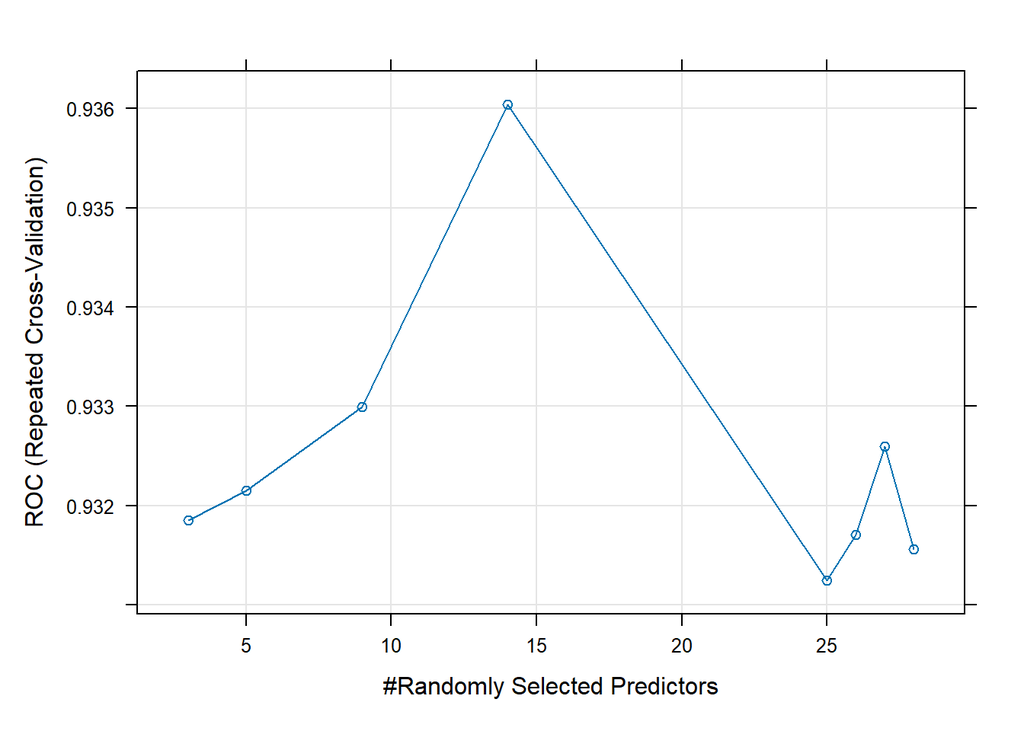

```r
plot(rfhyp)
```

#### Evaluacion

```r
library(pROC)
```

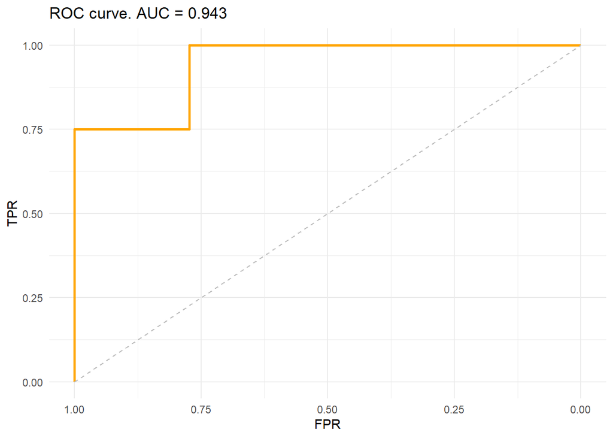

```r
predsRF <- predict(rfhyp, testing_dataSMOKE2, type="prob")
roc_curve <- roc(testing_dataSMOKE2$SCC, predsRF$yes, levels=c("no", "yes"))
ggroc(roc_curve, alpha = 1, colour = "orange", linetype = 1, size = 1) + theme_minimal() + ggtitle(sprintf("ROC curve. AUC = %.3f",roc_curve$auc)) +
 geom_segment(aes(x = 1, xend = 0, y = 0, yend = 1), color="grey", linetype="dashed") + xlab("FPR") + ylab("TPR")
```

**Nota** Como el numero de casos con los niveles “no” y “yes” en la variable SCC está muy desbalanceado este modelo no está generalizando correctamente.

```r
predsRF <- predict(rfhyp, testing_dataSMOKE2)

cm <- confusionMatrix(predsRF,
                as.factor(make.names(testing_dataSMOKE2$SMOKE)),
                positive="yes",
                dnn = c("Prediction", "Label")
                )
cm
```

```
## Confusion Matrix and Statistics
##
##           Label
## Prediction no yes
##        no  12  13
##        yes  1   0
##
##                Accuracy : 0.4615
##                  95% CI : (0.2659, 0.6663)
##     No Information Rate : 0.5
##     P-Value [Acc > NIR] : 0.721401
##
##                   Kappa : -0.0769
##
##  Mcnemar's Test P-Value : 0.003283
##
##             Sensitivity : 0.00000
##             Specificity : 0.92308
##          Pos Pred Value : 0.00000
##          Neg Pred Value : 0.48000
##              Prevalence : 0.50000
##          Detection Rate : 0.00000
##    Detection Prevalence : 0.03846
##       Balanced Accuracy : 0.46154
##
##        'Positive' Class : yes
##
```

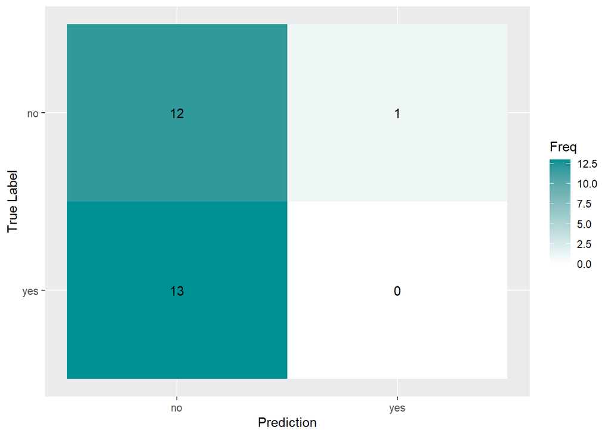

```r
ggplot(as.data.frame(cm$table), aes(Prediction,sort(Label,decreasing = T), fill= Freq)) +
        geom_tile() + geom_text(aes(label=Freq)) +
        scale_fill_gradient(low="white", high="#009194") +
        labs(x = "Prediction",y = "True Label") +
        scale_x_discrete(labels=c("no","yes")) +
        scale_y_discrete(labels=c("yes","no"))
```

NO se obtienen buenas predicciones con “yes”

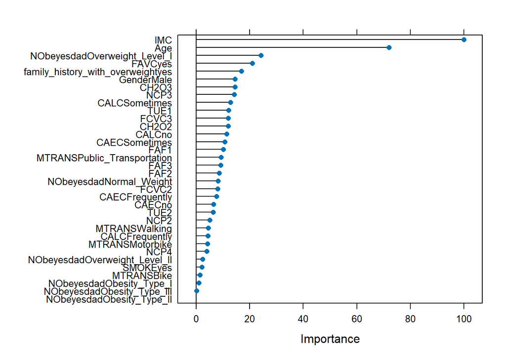

```r
plot(varImp(rfhyp))
```

Al parecer el modelo se explica mayormente con las variable IMC y AGE, es posible que el score mejore si excluimos las demas variables y solo se dejan estas 2 variables para entrenar el modelo.

## 2.2. Un modelo que detecte en base a los datos si un usuario controla o no lascalorías ingeridas.

### 2.2.1. Regresion Logística para SCC

En la siguiente consulta vemos que la data para la variable SCC está desbalanceada, a la hora de hacer el split debemos garantizar que en cada set de training y test contenga los dos niveles de etiquetado necesarios

```r
obesity.model.rescale %>%
  group_by(SCC) %>% summarise(count = n())
```

```
## # A tibble: 2 × 2
##     SCC count
##   <dbl> <int>
## 1     0  2015
## 2     1    96
```

el split de test se hará en base a la cantidad de data para test disponible

```r
96-round(96*0.3)
```

```
## [1] 67
```

#### Train Test split

```r
sample=round(96*0.3)
obesity.model.rescale %>%
  group_by(SCC) %>%
  mutate(num_rows= n()) %>%
  slice_sample(n=sample, weight_by=num_rows) %>%
  group_by(SCC) %>% summarise(count = n())
```

```
## # A tibble: 2 × 2
##     SCC count
##   <dbl> <int>
## 1     0    29
## 2     1    29
```

Agregar un indice para luego filtrar por este en el split

```r
obesity.model.rescale$index <- 1:nrow(obesity.model.rescale)
head(obesity.model.rescale)
```

```
##   Gender       Age family_history_with_overweight FAVC FCVC       NCP CAEC
## 1      0 0.1489362                              1    0  0.5 0.6666667    1
## 2      0 0.1489362                              1    0  1.0 0.6666667    1
## 3      1 0.1914894                              1    0  0.5 0.6666667    1
## 4      1 0.2765957                              0    0  1.0 0.6666667    1
## 5      1 0.1702128                              0    0  0.5 0.0000000    1
## 6      1 0.3191489                              0    1  0.5 0.6666667    1
##   SMOKE CH2O SCC       FAF TUE      CALC MTRANS NObeyesdad       IMC index
## 1     0  0.5   0 0.0000000 0.5 0.6666667   0.75  0.1666667 0.3011615     1
## 2     1  1.0   1 1.0000000 0.0 1.0000000   0.75  0.1666667 0.2972396     2
## 3     0  0.5   0 0.6666667 0.5 0.3333333   0.75  0.1666667 0.2847361     3
## 4     0  0.5   0 0.6666667 0.0 0.3333333   1.00  0.8333333 0.3663592     4
## 5     0  0.5   0 0.0000000 0.0 1.0000000   0.75  1.0000000 0.4057776     5
## 6     0  0.5   0 0.0000000 0.0 1.0000000   0.00  0.1666667 0.1903154     6
```

```r
str(obesity.model.rescale)
```

```
## 'data.frame':    2111 obs. of  17 variables:
##  $ Gender                        : num  0 0 1 1 1 1 0 1 1 1 ...
##  $ Age                           : num  0.149 0.149 0.191 0.277 0.17 ...
##  $ family_history_with_overweight: num  1 1 1 0 0 0 1 0 1 1 ...
##  $ FAVC                          : num  0 0 0 0 0 1 1 0 1 1 ...
##  $ FCVC                          : num  0.5 1 0.5 1 0.5 0.5 1 0.5 1 0.5 ...
##  $ NCP                           : num  0.667 0.667 0.667 0.667 0 ...
##  $ CAEC                          : num  1 1 1 1 1 1 1 1 1 1 ...
##  $ SMOKE                         : num  0 1 0 0 0 0 0 0 0 0 ...
##  $ CH2O                          : num  0.5 1 0.5 0.5 0.5 0.5 0.5 0.5 0.5 0.5 ...
##  $ SCC                           : num  0 1 0 0 0 0 0 0 0 0 ...
##  $ FAF                           : num  0 1 0.667 0.667 0 ...
##  $ TUE                           : num  0.5 0 0.5 0 0 0 0 0 0.5 0.5 ...
##  $ CALC                          : num  0.667 1 0.333 0.333 1 ...
##  $ MTRANS                        : num  0.75 0.75 0.75 1 0.75 0 0.5 0.75 0.75 0.75 ...
##  $ NObeyesdad                    : num  0.167 0.167 0.167 0.833 1 ...
##  $ IMC                           : num  0.301 0.297 0.285 0.366 0.406 ...
##  $ index                         : int  1 2 3 4 5 6 7 8 9 10 ...
```

Definir el dataset de test

```r
set.seed(42)

stratified_sample <- obesity.model.rescale %>%
  group_by(SCC) %>%
  mutate(num_rows= n()) %>%
  slice_sample(n=sample, weight_by=num_rows) %>%
  ungroup
```

```r
stratified_sample$index
```

```
##  [1] 1941 1986  640 1769 1389 1142 1580  309 1420 1517 1017 1546 1981  572 1027
## [16] 1993 2069  273 1052 1224 1916  317 2090 2004  189 1130  861 1918  993  877
## [31]  785  867  334  661   12  876   16  174  954  522  265  381   69  966  372
## [46]  964  893  602  965  521  237  240  335  792   54  738  633  128
```

```r
testing_dataSCC <- stratified_sample
training_dataSCC <- filter(obesity.model.rescale, !obesity.model.rescale$index %in% testing_dataSCC$index)
```

Verificamos que existan los dos niveles en la variable SCC

```r
training_dataSCC %>%
  group_by(SCC) %>% summarise(count = n())
```

```
## # A tibble: 2 × 2
##     SCC count
##   <dbl> <int>
## 1     0  1986
## 2     1    67
```

```r
testing_dataSCC %>%
  group_by(SCC) %>% summarise(count = n())
```

```
## # A tibble: 2 × 2
##     SCC count
##   <dbl> <int>
## 1     0    29
## 2     1    29
```

Una vez verificado el split se procede a borrar la columna index para no adjuntarla al modelo

```r
testing_dataSCC <- testing_dataSCC %>% select(-index,-num_rows)
training_dataSCC <- training_dataSCC %>% select(-index)
str(testing_dataSCC)
```

```
## tibble [58 × 16] (S3: tbl_df/tbl/data.frame)
##  $ Gender                        : num [1:58] 0 0 1 1 0 0 1 1 1 1 ...
##  $ Age                           : num [1:58] 0.2553 0.1489 0.0851 0.234 0.5532 ...
##  $ family_history_with_overweight: num [1:58] 1 1 1 1 1 1 1 0 1 1 ...
##  $ FAVC                          : num [1:58] 1 1 1 1 1 1 1 1 1 1 ...
##  $ FCVC                          : num [1:58] 1 1 0.5 0 0.5 0.5 1 1 1 1 ...
##  $ NCP                           : num [1:58] 0.667 0.667 0.667 0.667 0.667 ...
##  $ CAEC                          : num [1:58] 1 1 1 1 1 1 1 0 1 1 ...
##  $ SMOKE                         : num [1:58] 0 0 0 0 0 0 0 0 0 0 ...
##  $ CH2O                          : num [1:58] 1 0 0.5 0.5 0 0.5 0.5 1 0.5 0 ...
##  $ SCC                           : num [1:58] 0 0 0 0 0 0 0 0 0 0 ...
##  $ FAF                           : num [1:58] 0 0.667 0 0.333 0 ...
##  $ TUE                           : num [1:58] 0 0.5 1 0 0 0.5 0 0 0 0 ...
##  $ CALC                          : num [1:58] 1 1 1 1 0.667 ...
##  $ MTRANS                        : num [1:58] 0.75 0.75 0.75 0.75 0 0.75 0.75 0.75 0 0.75 ...
##  $ NObeyesdad                    : num [1:58] 0.667 0.667 0 0.5 0.333 ...
##  $ IMC                           : num [1:58] 0.765 0.843 0.125 0.618 0.512 ...
```

```r
str(training_dataSCC)
```

```
## 'data.frame':    2053 obs. of  16 variables:
##  $ Gender                        : num  0 0 1 1 1 1 0 1 1 1 ...
##  $ Age                           : num  0.149 0.149 0.191 0.277 0.17 ...
##  $ family_history_with_overweight: num  1 1 1 0 0 0 1 0 1 1 ...
##  $ FAVC                          : num  0 0 0 0 0 1 1 0 1 1 ...
##  $ FCVC                          : num  0.5 1 0.5 1 0.5 0.5 1 0.5 1 0.5 ...
##  $ NCP                           : num  0.667 0.667 0.667 0.667 0 ...
##  $ CAEC                          : num  1 1 1 1 1 1 1 1 1 1 ...
##  $ SMOKE                         : num  0 1 0 0 0 0 0 0 0 0 ...
##  $ CH2O                          : num  0.5 1 0.5 0.5 0.5 0.5 0.5 0.5 0.5 0.5 ...
##  $ SCC                           : num  0 1 0 0 0 0 0 0 0 0 ...
##  $ FAF                           : num  0 1 0.667 0.667 0 ...
##  $ TUE                           : num  0.5 0 0.5 0 0 0 0 0 0.5 0.5 ...
##  $ CALC                          : num  0.667 1 0.333 0.333 1 ...
##  $ MTRANS                        : num  0.75 0.75 0.75 1 0.75 0 0.5 0.75 0.75 0.75 ...
##  $ NObeyesdad                    : num  0.167 0.167 0.167 0.833 1 ...
##  $ IMC                           : num  0.301 0.297 0.285 0.366 0.406 ...
```

#### Modelo

```r
# Let's try to run a logistic regression
model <- glm(SCC ~.,family=binomial(link='logit'),data=training_dataSCC)
summary(model)
```

```
##
## Call:
## glm(formula = SCC ~ ., family = binomial(link = "logit"), data = training_dataSCC)
##
## Coefficients:
##                                Estimate Std. Error z value Pr(>|z|)
## (Intercept)                     -1.4770     1.0682  -1.383 0.166745
## Gender                          -0.6484     0.3050  -2.126 0.033519 *
## Age                             -2.9960     1.5148  -1.978 0.047951 *
## family_history_with_overweight  -0.5979     0.3186  -1.877 0.060582 .
## FAVC                            -1.0013     0.2869  -3.490 0.000483 ***
## FCVC                             1.7643     0.5487   3.215 0.001302 **
## NCP                              0.2787     0.4668   0.597 0.550424
## CAEC                            -0.4252     0.4582  -0.928 0.353383
## SMOKE                            1.3573     0.6328   2.145 0.031955 *
## CH2O                             0.4227     0.4094   1.032 0.301929
## FAF                              0.6844     0.4603   1.487 0.137049
## TUE                             -0.5833     0.4398  -1.326 0.184679
## CALC                            -0.5243     0.6845  -0.766 0.443662
## MTRANS                           0.1241     0.5611   0.221 0.824972
## NObeyesdad                       1.9808     0.5312   3.729 0.000192 ***
## IMC                             -5.8636     1.4641  -4.005 6.21e-05 ***
## ---
## Signif. codes:  0 '***' 0.001 '**' 0.01 '*' 0.05 '.' 0.1 ' ' 1
##
## (Dispersion parameter for binomial family taken to be 1)
##
##     Null deviance: 590.39  on 2052  degrees of freedom
## Residual deviance: 456.24  on 2037  degrees of freedom
## AIC: 488.24
##
## Number of Fisher Scoring iterations: 8
```

#### Predicciones Regresion Logística para SCC

```r
pred.trainSCC <- predict(model,testing_dataSCC, type = "response")

# Mean of the true prediction
mean(pred.trainSCC==testing_dataSCC$SCC)
```

```
## [1] 0
```

```r
summary(pred.trainSCC)
```

```
##     Min.  1st Qu.   Median     Mean  3rd Qu.     Max.
## 0.000682 0.004580 0.034879 0.069616 0.094023 0.522689
```

#### Evaluacion del modelo de Regresion Logística para SCC

```r
pred.trainSCC <- ifelse(pred.trainSCC > 0.0025,1,0)
t1<-table(pred.trainSCC,testing_dataSCC$SCC)
# Presicion and recall of the model
presicion<- t1[1,1]/(sum(t1[1,]))
recall<- t1[1,1]/(sum(t1[,1]))
presicion
```

```
## [1] 0.8
```

```r
recall
```

```
## [1] 0.137931
```

```r
# F1 score
F1<- 2*presicion*recall/(presicion+recall)
F1
```

```
## [1] 0.2352941
```

Dado que el índice de ajuste ha tenido que ser reducido hasta 0.0025 para conseguir la probabilidad de predicción deseada podemos decir que este sistema de ajuste no es concluyente ya que da lugar a un efecto de sobreajuste muy dificil de compensar. Otras opciones sería reducir la dimensionalidad o quitar variables para reducir el nivel de ruido en el modelo.

### 2.2.2. Random Forest para SCC

Para random forest utilizaremos la data sin transformar a numericos, pero tambien iniciaremos con definir el dataset de test para garantizar que en test existen los dos niveles de etiquetado

#### Train Test split

```r
sample=round(96*0.3)
obesity.model %>%
  group_by(SCC) %>%
  mutate(num_rows= n()) %>%
  slice_sample(n=sample, weight_by=num_rows) %>%
  group_by(SCC) %>% summarise(count = n())
```

```
## # A tibble: 2 × 2
##   SCC   count
##   <fct> <int>
## 1 no       29
## 2 yes      29
```

Agregar un indice para luego filtrar por este en el split

```r
obesity.model$index <- 1:nrow(obesity.model)
head(obesity.model)
```

```
##   Gender Age family_history_with_overweight FAVC FCVC NCP      CAEC SMOKE CH2O
## 1 Female  21                            yes   no    2   3 Sometimes    no    2
## 2 Female  21                            yes   no    3   3 Sometimes   yes    3
## 3   Male  23                            yes   no    2   3 Sometimes    no    2
## 4   Male  27                             no   no    3   3 Sometimes    no    2
## 5   Male  22                             no   no    2   1 Sometimes    no    2
## 6   Male  29                             no  yes    2   3 Sometimes    no    2
##   SCC FAF TUE       CALC                MTRANS          NObeyesdad      IMC
## 1  no   0   1         no Public_Transportation       Normal_Weight 24.38653
## 2 yes   3   0  Sometimes Public_Transportation       Normal_Weight 24.23823
## 3  no   2   1 Frequently Public_Transportation       Normal_Weight 23.76543
## 4  no   2   0 Frequently               Walking  Overweight_Level_I 26.85185
## 5  no   0   0  Sometimes Public_Transportation Overweight_Level_II 28.34238
## 6  no   0   0  Sometimes            Automobile       Normal_Weight 20.19509
##   index
## 1     1
## 2     2
## 3     3
## 4     4
## 5     5
## 6     6
```

```r
str(obesity.model)
```

```
## 'data.frame':    2111 obs. of  17 variables:
##  $ Gender                        : Factor w/ 2 levels "Female","Male": 1 1 2 2 2 2 1 2 2 2 ...
##  $ Age                           : num  21 21 23 27 22 29 23 22 24 22 ...
##  $ family_history_with_overweight: Factor w/ 2 levels "no","yes": 2 2 2 1 1 1 2 1 2 2 ...
##  $ FAVC                          : Factor w/ 2 levels "no","yes": 1 1 1 1 1 2 2 1 2 2 ...
##  $ FCVC                          : Factor w/ 3 levels "1","2","3": 2 3 2 3 2 2 3 2 3 2 ...
##  $ NCP                           : Factor w/ 4 levels "1","2","3","4": 3 3 3 3 1 3 3 3 3 3 ...
##  $ CAEC                          : Factor w/ 4 levels "Always","Frequently",..: 4 4 4 4 4 4 4 4 4 4 ...
##  $ SMOKE                         : Factor w/ 2 levels "no","yes": 1 2 1 1 1 1 1 1 1 1 ...
##  $ CH2O                          : Factor w/ 3 levels "1","2","3": 2 3 2 2 2 2 2 2 2 2 ...
##  $ SCC                           : Factor w/ 2 levels "no","yes": 1 2 1 1 1 1 1 1 1 1 ...
##  $ FAF                           : Factor w/ 4 levels "0","1","2","3": 1 4 3 3 1 1 2 4 2 2 ...
##  $ TUE                           : Factor w/ 3 levels "0","1","2": 2 1 2 1 1 1 1 1 2 2 ...
##  $ CALC                          : Factor w/ 4 levels "Always","Frequently",..: 3 4 2 2 4 4 4 4 2 3 ...
##  $ MTRANS                        : Factor w/ 5 levels "Automobile","Bike",..: 4 4 4 5 4 1 3 4 4 4 ...
##  $ NObeyesdad                    : Factor w/ 7 levels "Insufficient_Weight",..: 2 2 2 6 7 2 2 2 2 2 ...
##  $ IMC                           : num  24.4 24.2 23.8 26.9 28.3 ...
##  $ index                         : int  1 2 3 4 5 6 7 8 9 10 ...
```

Definir el dataset de test

```r
set.seed(42)

stratified_sample2 <- obesity.model %>%
  group_by(SCC) %>%
  mutate(num_rows= n()) %>%
  slice_sample(n=sample, weight_by=num_rows) %>%
  ungroup
```

```r
stratified_sample2$index
```

```
##  [1] 1941 1986  640 1769 1389 1142 1580  309 1420 1517 1017 1546 1981  572 1027
## [16] 1993 2069  273 1052 1224 1916  317 2090 2004  189 1130  861 1918  993  877
## [31]  785  867  334  661   12  876   16  174  954  522  265  381   69  966  372
## [46]  964  893  602  965  521  237  240  335  792   54  738  633  128
```

```r
testing_dataSCC2 <- stratified_sample2
training_dataSCC2 <- filter(obesity.model, !obesity.model$index %in% testing_dataSCC2$index)
```

Verificamos que existan los dos niveles en la variable SCC

```r
training_dataSCC2 %>%
  group_by(SCC) %>% summarise(count = n())
```

```
## # A tibble: 2 × 2
##   SCC   count
##   <fct> <int>
## 1 no     1986
## 2 yes      67
```

```r
testing_dataSCC2 %>%
  group_by(SCC) %>% summarise(count = n())
```

```
## # A tibble: 2 × 2
##   SCC   count
##   <fct> <int>
## 1 no       29
## 2 yes      29
```

Una vez verificado el split se procede a borrar la columna index para no adjuntarla al modelo

```r
testing_dataSCC2 <- testing_dataSCC2 %>% select(-index,-num_rows)
training_dataSCC2 <- training_dataSCC2 %>% select(-index)
str(testing_dataSCC2)
```

```
## tibble [58 × 16] (S3: tbl_df/tbl/data.frame)
##  $ Gender                        : Factor w/ 2 levels "Female","Male": 1 1 2 2 1 1 2 2 2 2 ...
##  $ Age                           : num [1:58] 26 21 18 25 40 23 23 20 32 33 ...
##  $ family_history_with_overweight: Factor w/ 2 levels "no","yes": 2 2 2 2 2 2 2 1 2 2 ...
##  $ FAVC                          : Factor w/ 2 levels "no","yes": 2 2 2 2 2 2 2 2 2 2 ...
##  $ FCVC                          : Factor w/ 3 levels "1","2","3": 3 3 2 1 2 2 3 3 3 3 ...
##  $ NCP                           : Factor w/ 4 levels "1","2","3","4": 3 3 3 3 3 3 3 4 2 2 ...
##  $ CAEC                          : Factor w/ 4 levels "Always","Frequently",..: 4 4 4 4 4 4 4 1 4 4 ...
##  $ SMOKE                         : Factor w/ 2 levels "no","yes": 1 1 1 1 1 1 1 1 1 1 ...
##  $ CH2O                          : Factor w/ 3 levels "1","2","3": 3 1 2 2 1 2 2 3 2 1 ...
##  $ SCC                           : Factor w/ 2 levels "no","yes": 1 1 1 1 1 1 1 1 1 1 ...
##  $ FAF                           : Factor w/ 4 levels "0","1","2","3": 1 3 1 2 1 1 2 3 3 3 ...
##  $ TUE                           : Factor w/ 3 levels "0","1","2": 1 2 3 1 1 2 1 1 1 1 ...
##  $ CALC                          : Factor w/ 4 levels "Always","Frequently",..: 4 4 4 4 3 3 4 4 4 3 ...
##  $ MTRANS                        : Factor w/ 5 levels "Automobile","Bike",..: 4 4 4 4 1 4 4 4 1 4 ...
##  $ NObeyesdad                    : Factor w/ 7 levels "Insufficient_Weight",..: 5 5 1 4 3 7 4 2 3 4 ...
##  $ IMC                           : num [1:58] 41.9 44.9 17.7 36.4 32.4 ...
```

```r
str(training_dataSCC2)
```

```
## 'data.frame':    2053 obs. of  16 variables:
##  $ Gender                        : Factor w/ 2 levels "Female","Male": 1 1 2 2 2 2 1 2 2 2 ...
##  $ Age                           : num  21 21 23 27 22 29 23 22 24 22 ...
##  $ family_history_with_overweight: Factor w/ 2 levels "no","yes": 2 2 2 1 1 1 2 1 2 2 ...
##  $ FAVC                          : Factor w/ 2 levels "no","yes": 1 1 1 1 1 2 2 1 2 2 ...
##  $ FCVC                          : Factor w/ 3 levels "1","2","3": 2 3 2 3 2 2 3 2 3 2 ...
##  $ NCP                           : Factor w/ 4 levels "1","2","3","4": 3 3 3 3 1 3 3 3 3 3 ...
##  $ CAEC                          : Factor w/ 4 levels "Always","Frequently",..: 4 4 4 4 4 4 4 4 4 4 ...
##  $ SMOKE                         : Factor w/ 2 levels "no","yes": 1 2 1 1 1 1 1 1 1 1 ...
##  $ CH2O                          : Factor w/ 3 levels "1","2","3": 2 3 2 2 2 2 2 2 2 2 ...
##  $ SCC                           : Factor w/ 2 levels "no","yes": 1 2 1 1 1 1 1 1 1 1 ...
##  $ FAF                           : Factor w/ 4 levels "0","1","2","3": 1 4 3 3 1 1 2 4 2 2 ...
##  $ TUE                           : Factor w/ 3 levels "0","1","2": 2 1 2 1 1 1 1 1 2 2 ...
##  $ CALC                          : Factor w/ 4 levels "Always","Frequently",..: 3 4 2 2 4 4 4 4 2 3 ...
##  $ MTRANS                        : Factor w/ 5 levels "Automobile","Bike",..: 4 4 4 5 4 1 3 4 4 4 ...
##  $ NObeyesdad                    : Factor w/ 7 levels "Insufficient_Weight",..: 2 2 2 6 7 2 2 2 2 2 ...
##  $ IMC                           : num  24.4 24.2 23.8 26.9 28.3 ...
```

#### Modelo

```r
set.seed(123)
train.controlSCC <- trainControl(method = "repeatedcv",
                           number = 3,
                           repeats = 3,
                           classProbs = TRUE,
                           summaryFunction = twoClassSummary,
                           search = "random")
```

```r
rfhyp <- train(make.names(SCC)~ ., data=training_dataSCC2,
              trControl=train.controlSCC,
              method='rf',
              metric='ROC',
              tuneLength=10
              )
print(rfhyp)
```

```
## Random Forest
##
## 2053 samples
##   15 predictor
##    2 classes: 'no', 'yes'
##
## No pre-processing
## Resampling: Cross-Validated (3 fold, repeated 3 times)
## Summary of sample sizes: 1369, 1369, 1368, 1368, 1369, 1369, ...
## Resampling results across tuning parameters:
##
##   mtry  ROC        Sens       Spec
##    3    0.9270047  1.0000000  0.01998243
##    5    0.9259711  1.0000000  0.08981116
##    9    0.9256686  0.9988251  0.15458937
##   14    0.9207808  0.9984894  0.17457181
##   25    0.9212087  0.9973145  0.16425121
##   26    0.9164811  0.9971467  0.16447079
##   27    0.9181157  0.9971467  0.16403162
##   28    0.9187063  0.9971467  0.15920070
##
## ROC was used to select the optimal model using the largest value.
## The final value used for the model was mtry = 3.
```

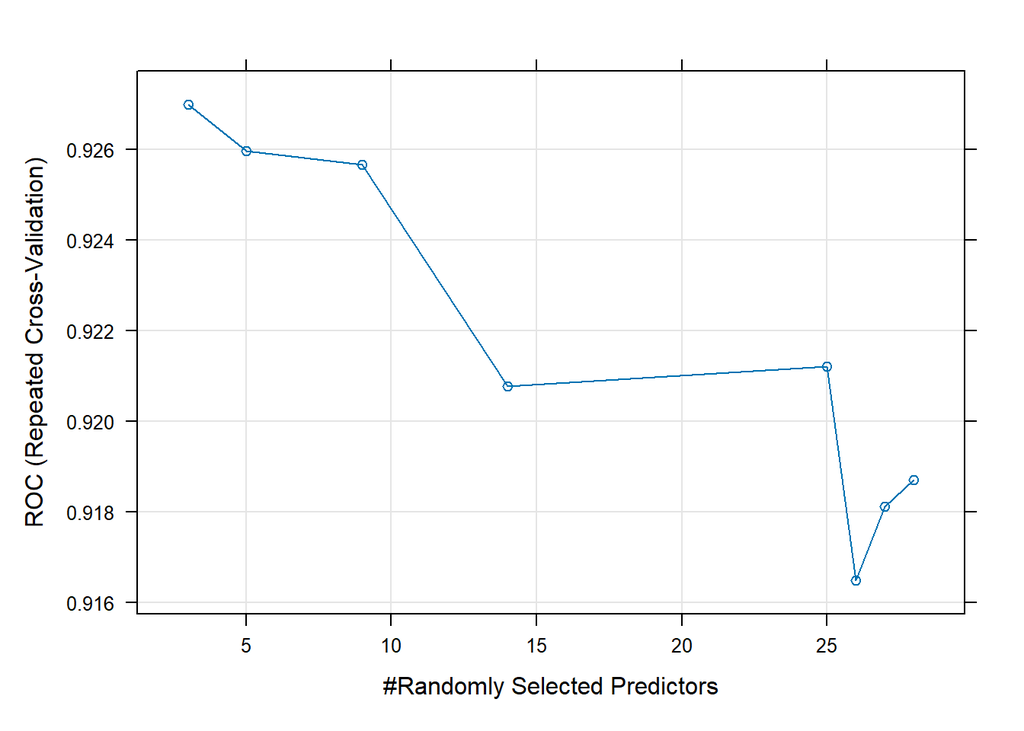

```r
plot(rfhyp)
```

#### Evaluacion

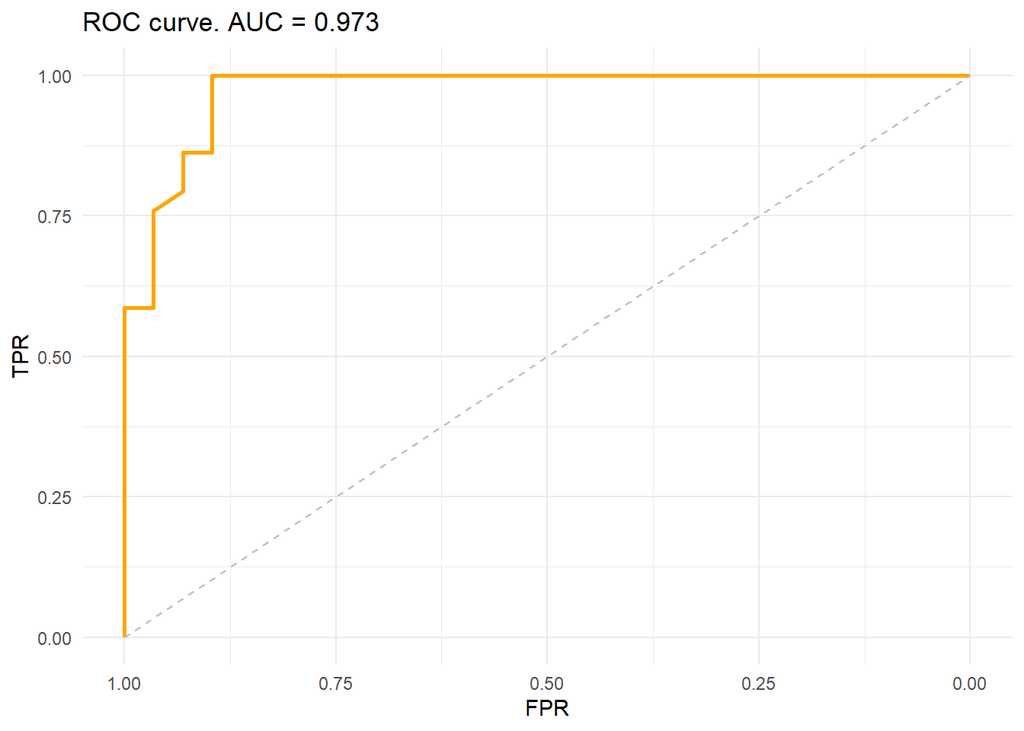

```r
library(pROC)
predsRF <- predict(rfhyp, testing_dataSCC2, type="prob")
roc_curve <- roc(testing_dataSCC2$SCC, predsRF$yes, levels=c("no", "yes"))
ggroc(roc_curve, alpha = 1, colour = "orange", linetype = 1, size = 1) + theme_minimal() + ggtitle(sprintf("ROC curve. AUC = %.3f",roc_curve$auc)) +
 geom_segment(aes(x = 1, xend = 0, y = 0, yend = 1), color="grey", linetype="dashed") + xlab("FPR") + ylab("TPR")
```

**Nota** Como el numero de casos con los niveles “no” y “yes” en la variable SCC está muy desbalanceado este modelo no está generalizando correctamente.

```r
predsRF <- predict(rfhyp, testing_dataSCC2)

cm <- confusionMatrix(predsRF,
                as.factor(make.names(testing_dataSCC2$SCC)),
                positive="yes",
                dnn = c("Prediction", "Label")
                )
cm
```

```
## Confusion Matrix and Statistics
##
##           Label
## Prediction no yes
##        no  29  28
##        yes  0   1
##
##                Accuracy : 0.5172
##                  95% CI : (0.3822, 0.6505)
##     No Information Rate : 0.5
##     P-Value [Acc > NIR] : 0.4478
##
##                   Kappa : 0.0345
##
##  Mcnemar's Test P-Value : 3.352e-07
##
##             Sensitivity : 0.03448
##             Specificity : 1.00000
##          Pos Pred Value : 1.00000
##          Neg Pred Value : 0.50877
##              Prevalence : 0.50000
##          Detection Rate : 0.01724
##    Detection Prevalence : 0.01724
##       Balanced Accuracy : 0.51724
##
##        'Positive' Class : yes
##
```

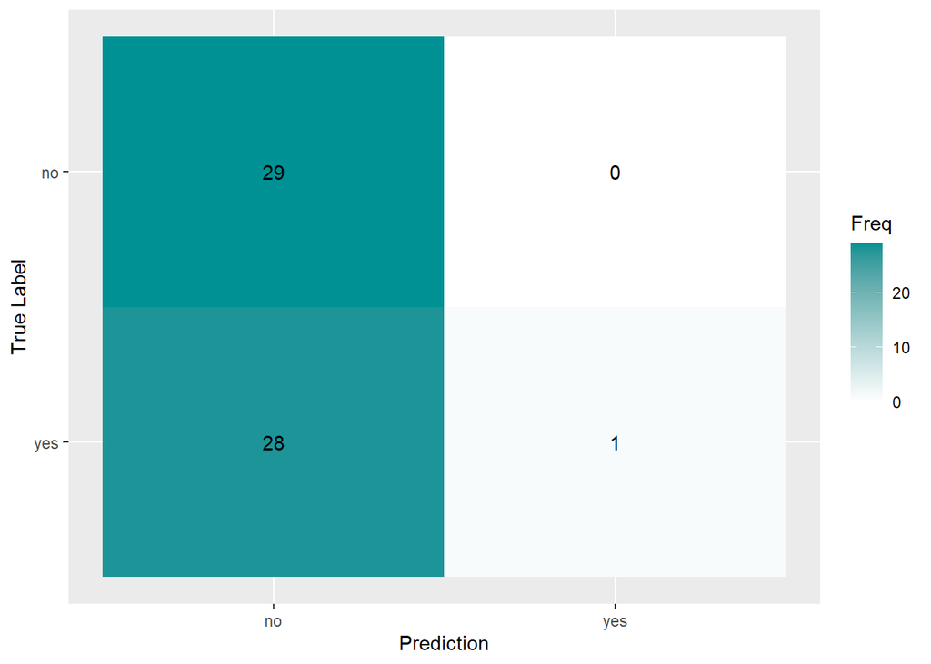

```r
ggplot(as.data.frame(cm$table), aes(Prediction,sort(Label,decreasing = T), fill= Freq)) +
        geom_tile() + geom_text(aes(label=Freq)) +
        scale_fill_gradient(low="white", high="#009194") +
        labs(x = "Prediction",y = "True Label") +
        scale_x_discrete(labels=c("no","yes")) +
        scale_y_discrete(labels=c("yes","no"))
```

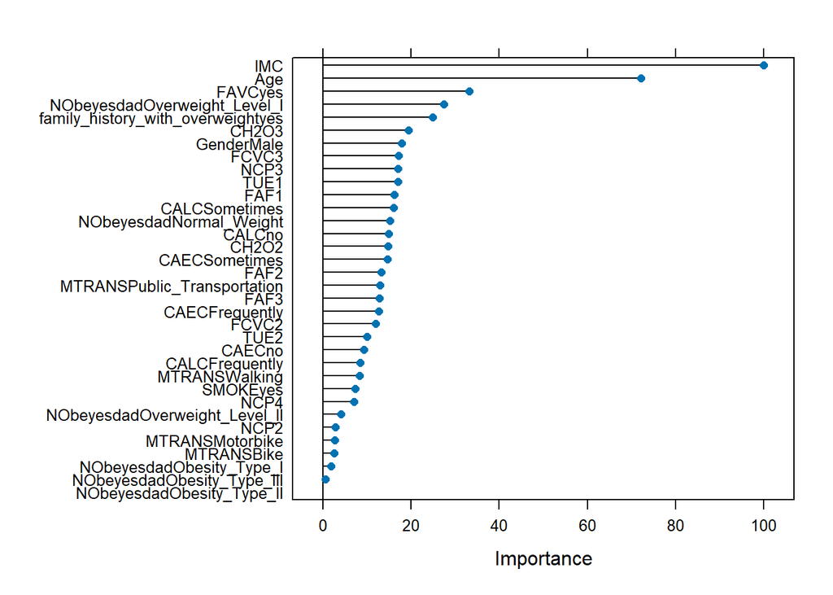

```r
plot(varImp(rfhyp))
```

Al parecer el modelo se explica mayormente con las variable IMC AGE y FAVC, es posible que el score mejore si excluimos las demas variables y solo se dejan estas 3 variables para entrenar el modelo.

# 3. Obtener un modelo predictivo de clasificación multiclase que en base a los datos obtenga el grado de obesidad de una persona. Evaluar el modelo y analizar las métricas pertinentes.

En primer lugar realizaremos un particionado del dataset previamente procesado para dividirlo en: conjunto de entrenamiento y conjunto de test.

```r
set.seed(117)
particion_3 = sample(1:nrow(obesity.model), size = (0.7* nrow(obesity.model)))
train_3 = obesity.model[particion_3,]
test_3 = obesity.model[-particion_3,]
```

Excluir variable de index

```r
train_3 = train_3 %>% select(-index)
test_3 = test_3 %>% select(-index)
```

Una vez tenemos los dos conjuntos podemos aplicar los modelos predictivos.

## 3.1 Árbol de decisión.

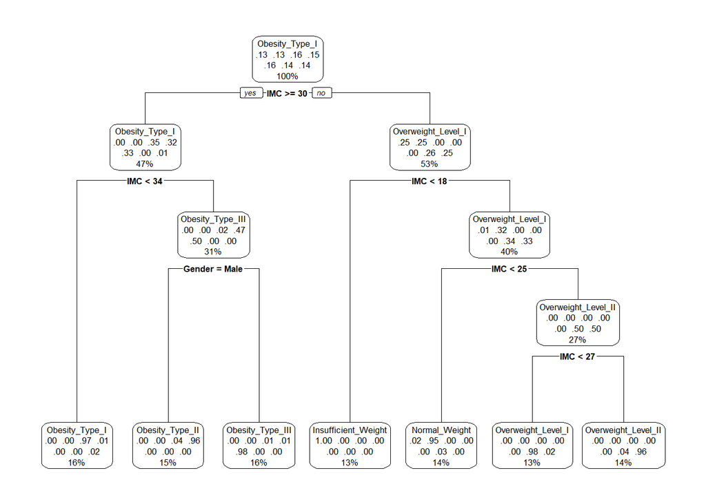

```r
model_ad3 <- rpart(NObeyesdad ~. , data=train_3 , method="class")
rpart.plot(model_ad3)
```

### Evaluacion

```r
pred.train.ad3 <- predict(model_ad3,test_3,type = "class")
mean(pred.train.ad3==test_3$NObeyesdad)
```

```
## [1] 0.9794953
```

```r
t2 <- table(pred.train.ad3,test_3$NObeyesdad)

presicion_dt3<- t2[1,1]/(sum(t2[1,]))
recall_dt3<- t2[1,1]/(sum(t2[,1]))
presicion_dt3
```

```
## [1] 1
```

```r
recall_dt3
```

```
## [1] 0.987013
```

```r
F1_dt3<- 2*presicion_dt3*recall_dt3/(presicion_dt3+recall_dt3)
F1_dt3
```

```
## [1] 0.9934641
```

## 3.2 Random Forest.

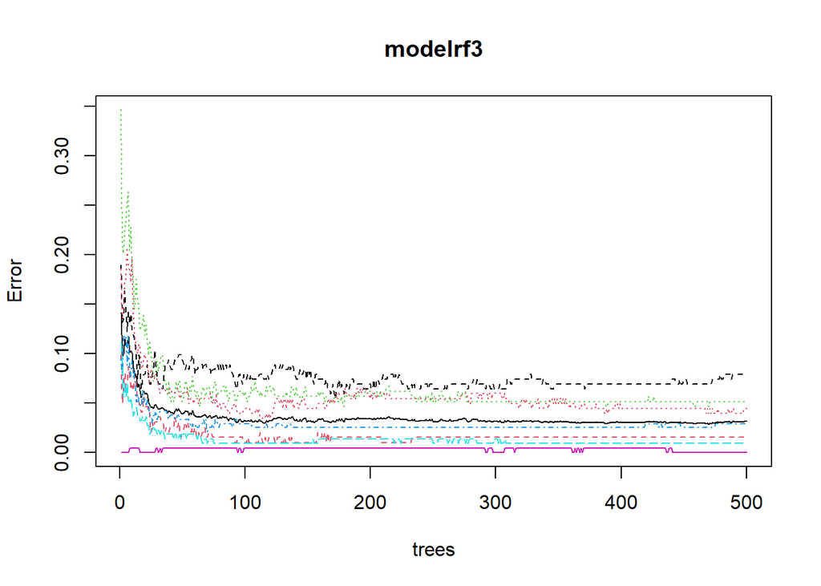

```r
x_3 = train_3 %>% select(-NObeyesdad)
modelrf3 = randomForest(x=x_3,
               y=train_3$NObeyesdad,
               importance=TRUE
               )
plot(modelrf3)
```

### Evaluacion

```r
pred.train.rf3 <- predict(modelrf3,test_3)
sprintf("Accuracy3: %f", (mean(pred.train.rf3==test_3$NObeyesdad)))
```

```
## [1] "Accuracy3: 0.976341"
```

```r
t13<-table(pred.train.rf3,test_3$NObeyesdad)
prec3<- t13[1,1]/(sum(t13[1,]))
recall3<- t13[1,1]/(sum(t13[,1]))
F13<- 2*prec3*recall3/(prec3+recall3)

sprintf("Presicion3: %f", prec3)
```

```
## [1] "Presicion3: 0.987179"
```

```r
sprintf("Recall3: %f", recall3[1])
```

```
## [1] "Recall3: 1.000000"
```

```r
sprintf("F1 score3: %f", F13)
```

```
## [1] "F1 score3: 0.993548"
```

## Análisis de resultados.

Vemos que en ambos modelos se obtienen F1 score muy próximos a 1 o iguales a 1, de hecho, no tendría sentido realizar el Random Forest después de ver el resultado del árbol de decisión. Este resultado tiene bastante sentido porque se ha incluido la variable “IMC” que esta muy correlacionada con el grado de obesidad, ya que a partir de una se obtiene directamente la otra. Vamos a repetir el proceso esta vez sin tener en cuenta la variable “IMC” para ver cómo afecta a los modelos.

## 3.3 Árbol de decisión sin variable “IMC”.

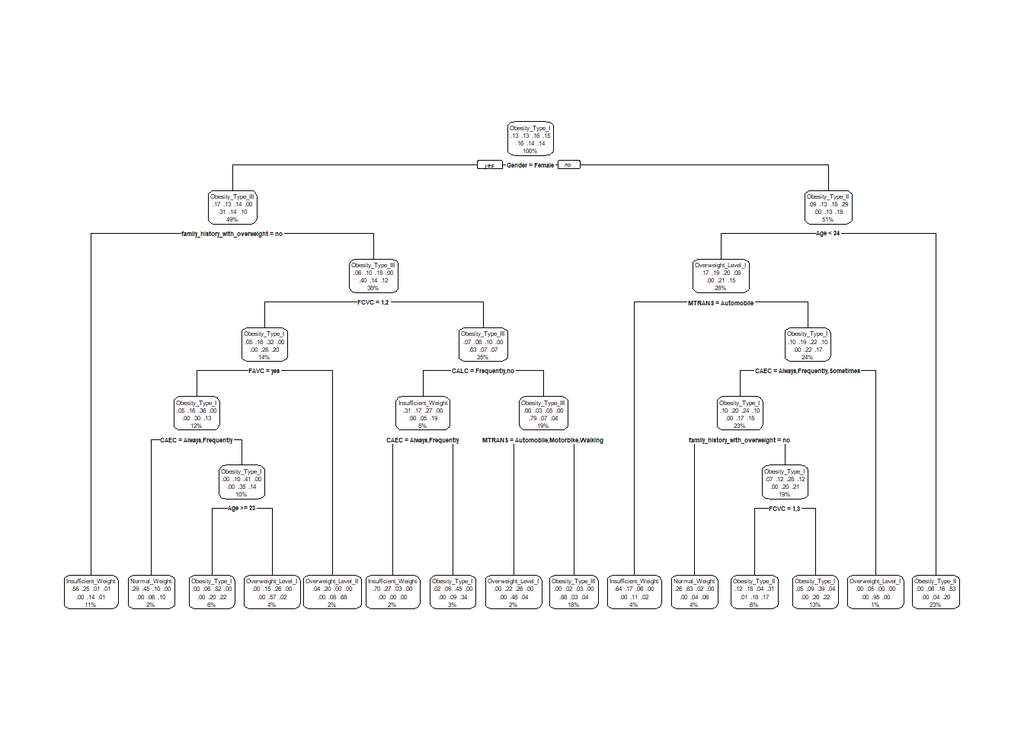

```r
model_ad3.1 <- rpart(NObeyesdad ~ Gender + Age + family_history_with_overweight + FAVC + FCVC + NCP + CAEC + SMOKE + CH2O + SCC + FAF + CALC + MTRANS + NObeyesdad, data=train_3 , method="class")
rpart.plot(model_ad3.1)
```

### Evaluacion

```r
pred.train.ad3.1 <- predict(model_ad3.1,test_3,type = "class")
mean(pred.train.ad3.1==test_3$NObeyesdad)
```

```
## [1] 0.5473186
```

```r
t2.3<-table(pred.train.ad3.1,test_3$NObeyesdad)

presicion_ad3.1<- t2.3[1,1]/(sum(t2[1,]))
recall_ad3.1<- t2.3[1,1]/(sum(t2[,1]))
presicion_ad3.1
```

```
## [1] 0.6842105
```

```r
recall_ad3.1
```

```
## [1] 0.6753247
```

```r
F1_ad3.1<- 2*presicion_ad3.1*recall_ad3.1/(presicion_ad3.1+recall_ad3.1)
F1_ad3.1
```

```
## [1] 0.6797386
```

Aquí ya vemos que el árbol de decisión ha cambiado bastante, aumentado considerablemente el numero de nodos y bajado a un F1 score de 0.68 aprox. el cual sería algo bajo como modelo de predicción. Ahora si tiene sentido aplicar un Random Forest para ver si mejoramos la precisión del modelo predictivo.

## 3.4 Random Forest sin la variable “IMC”.

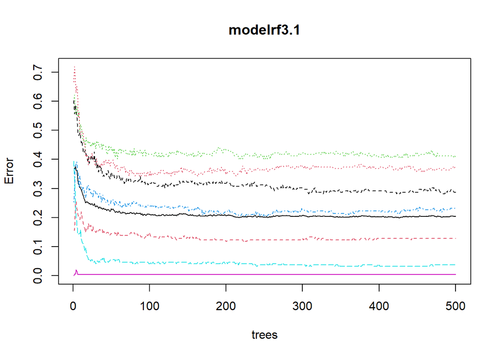

```r
modelrf3.1 = randomForest(x=x_3 %>% select(-IMC),
               y=train_3$NObeyesdad,
               importance=TRUE
               )
plot(modelrf3.1)
```

### Evaluacion

```r
pred.train.rf3.1 <- predict(modelrf3.1,test_3)
sprintf("Accuracy3.1: %f", (mean(pred.train.rf3.1==test_3$NObeyesdad)))
```

```
## [1] "Accuracy3.1: 0.763407"
```

```r
t13.1<-table(pred.train.rf3.1,test_3$NObeyesdad)
prec3.1<- t13.1[1,1]/(sum(t13.1[1,]))
recall3.1<- t13.1[1,1]/(sum(t13.1[,1]))
F13.1<- 2*prec3.1*recall3.1/(prec3.1+recall3.1)

sprintf("Presicion3.1: %f", prec3.1)
```

```
## [1] "Presicion3.1: 0.744186"
```

```r
sprintf("Recall3.1: %f", recall3.1[1])
```

```
## [1] "Recall3.1: 0.831169"
```

```r
sprintf("F1 score3.1: %f", F13.1)
```

```
## [1] "F1 score3.1: 0.785276"
```

# 4. Aplicar técnicas de clustering para segmentar a la población del dataset.Evaluarlos modelos y analizar las métricas pertinentes

Para clustering no será necesaria la variable NObeyesdad puesto que va ser la segmentacion que inferiran los distintos modelos, y se utilizaran las variables transformadas a numericas y rescaladas

```r
obesity.cluster= obesity.model.rescale %>%
  select(-c(NObeyesdad,index))
head(obesity.cluster)
```

```
##   Gender       Age family_history_with_overweight FAVC FCVC       NCP CAEC
## 1      0 0.1489362                              1    0  0.5 0.6666667    1
## 2      0 0.1489362                              1    0  1.0 0.6666667    1
## 3      1 0.1914894                              1    0  0.5 0.6666667    1
## 4      1 0.2765957                              0    0  1.0 0.6666667    1
## 5      1 0.1702128                              0    0  0.5 0.0000000    1
## 6      1 0.3191489                              0    1  0.5 0.6666667    1
##   SMOKE CH2O SCC       FAF TUE      CALC MTRANS       IMC
## 1     0  0.5   0 0.0000000 0.5 0.6666667   0.75 0.3011615
## 2     1  1.0   1 1.0000000 0.0 1.0000000   0.75 0.2972396
## 3     0  0.5   0 0.6666667 0.5 0.3333333   0.75 0.2847361
## 4     0  0.5   0 0.6666667 0.0 0.3333333   1.00 0.3663592
## 5     0  0.5   0 0.0000000 0.0 1.0000000   0.75 0.4057776
## 6     0  0.5   0 0.0000000 0.0 1.0000000   0.00 0.1903154
```

## K-means

```r
str(obesity.cluster)
```

```
## 'data.frame':    2111 obs. of  15 variables:
##  $ Gender                        : num  0 0 1 1 1 1 0 1 1 1 ...
##  $ Age                           : num  0.149 0.149 0.191 0.277 0.17 ...
##  $ family_history_with_overweight: num  1 1 1 0 0 0 1 0 1 1 ...
##  $ FAVC                          : num  0 0 0 0 0 1 1 0 1 1 ...
##  $ FCVC                          : num  0.5 1 0.5 1 0.5 0.5 1 0.5 1 0.5 ...
##  $ NCP                           : num  0.667 0.667 0.667 0.667 0 ...
##  $ CAEC                          : num  1 1 1 1 1 1 1 1 1 1 ...
##  $ SMOKE                         : num  0 1 0 0 0 0 0 0 0 0 ...
##  $ CH2O                          : num  0.5 1 0.5 0.5 0.5 0.5 0.5 0.5 0.5 0.5 ...
##  $ SCC                           : num  0 1 0 0 0 0 0 0 0 0 ...
##  $ FAF                           : num  0 1 0.667 0.667 0 ...
##  $ TUE                           : num  0.5 0 0.5 0 0 0 0 0 0.5 0.5 ...
##  $ CALC                          : num  0.667 1 0.333 0.333 1 ...
##  $ MTRANS                        : num  0.75 0.75 0.75 1 0.75 0 0.5 0.75 0.75 0.75 ...
##  $ IMC                           : num  0.301 0.297 0.285 0.366 0.406 ...
```

```r
set.seed(101)
obesityClusterKNN <- kmeans(obesity.cluster[,1:15], centers=3, nstart=3)
obesityClusterKNN
```

```
## K-means clustering with 3 clusters of sizes 811, 915, 385
##
## Cluster means:
##      Gender       Age family_history_with_overweight      FAVC      FCVC
## 1 0.0000000 0.2320487                              1 0.9001233 0.8002466
## 2 1.0000000 0.2331124                              1 0.9289617 0.6393443
## 3 0.3974026 0.1606521                              0 0.7428571 0.6974026
##         NCP      CAEC      SMOKE      CH2O        SCC       FAF       TUE
## 1 0.5511714 0.9140978 0.01726264 0.5277435 0.03699137 0.2630497 0.3267571
## 2 0.5879781 0.9391621 0.02622951 0.5322404 0.01857923 0.3857923 0.3448087
## 3 0.5264069 0.7246753 0.01558442 0.4051948 0.12727273 0.3688312 0.3142857
##        CALC    MTRANS       IMC
## 1 0.8795725 0.6205302 0.5298592
## 2 0.8714026 0.5368852 0.4547750
## 3 0.8822511 0.6590909 0.2248378
```

[output cut: 69 more lines]

```r
table(obesityClusterKNN$cluster)
```

```
##
##   1   2   3
## 811 915 385
```